# All Data Analyses of AUDIO Swabian experiment: IAT & preselection

Judit Vari

20 2 2024

# 1. Prep

## 1.1. session & all data

*load libraries*

*read cleaned data*

*assign classes*

## 1.2. Pre-selection of leadership attributes

*separate pre-selection phase data from IAT data* Part of separate cleaned data set only with attributes: variable “cat1_: leadership1” = „mit Charisma“ variable “cat2_: leadership2” = „ohne Charisma“ variables “cat1/2_list”: Logging of final selection for leadership attributes of leadership category 1. Each attribute with associated rank first 6 of variables “cat1/2_list” used for IAT.

Part of main cleaned data set containing meta data of selection process such as following 4 variables: variable “count_ click_sequence”: Count of sequences (1 sequence = 2 clicks: 1x selection of attribute + 1x allocation to place) min. 20 variable “count_ check_selection”: Count of calling check-up screen to revise pre-selection ((„Überprüfen Sie Ihre Auswahl…“) min. 1 variable”n_practice”: Count of block no. of pre-selection practice (min: 0-3, max. 7) variable “accuracy_practice_trial”: Accuracy of block no. (max. 1 = 100%)

## 1.2. exclude practice blocks & filter speeders/ laggers

*create data set with only IAT data*

*include only four experimental blocks* exclude practice blocks 1, 2 and 5 (after key switch) and include only experimental blocks 3,4,6,7 following Greenwld et al.

*exclude speeders & laggers* exclude speeders: Greenwald et al: exclusion of entire data from subjects for whom more than 10% of trials have latencies faster than 300 ms Experimental block 3 has 20 trial, block 4 has 40 trials, block 6 has 20 trials, block 7 has 40 trials FourExpBlock = 120 trials 10% = 12, find pp whose RT is <300 ms for more than 12 trials

*understand speeders* examine two participants/ speeders one_speeder1: 78 rows under 300, but acc 66 % one_speeder2: 34 rows under 300 but acc. 60.525 -> speeder only in last experimental block

*exclude speeders & laggers* decision: Exclude participants with more than 10% fast (<300ms) trials & Exclude individual trials longer than 10,000 ms do not exclude only specific experimental block (such as one_speeder2) or speeders with specific accuracy, rather follow Greenwald et al

## 1.3. Descriptives IAT cleaning

*How many participants excluded for speeders & laggers?* Original no. participants

```
## [1] 737
```

Cleaned data no. participants

```
## [1] 616
```

## 1.4. Treatment of incorrect trials

replaced Reaction times for error trials with: mean of correct responses plus 600 ms as penalty (other option in literature: the mean of correct responses in the block in which the error occurred plus a penalty of 2x the standard deviation of correct responses in the block in which the error occurred.)

*write clean IAT data to csv*

##1.5. Age related slowing  
*z-scores to address age-related slowing with data transformation (and not only age as co-variant)*

Hummert: Using the Implicit Association Test to Measure Age Differences in Implicit Social Cognitions Faust, M. E., Balota, D. A., Spieler, D. H., & Ferraro, F. R. (1999). Individual differences in information-processing rate and amount: Implications for group differences in response latency. Psychological Bulletin, 125, 777–799.

Several statistical transformations applied to response latencies to control for general age-related slowing. natural logs, proportion (dividing each individual’s mean latency on one task by the person’s mean latency on all tasks), task-level z scores (converting each individual’s mean latency on trials for one task into a z score on the basis of the person’s mean latency and standard deviation on all tasks), and trial-level z scores (using each person’s overall mean and standard deviation to convert each trial into a z score)

now: trial level z score:

computed each participant’s mean and standard deviation across all trials all experimental blocks, use values used to convert pp’s trial latencies into z scores

## 1.6. Create in- and outgroup subsets

Separate ingroup from outgroup based on exposure to Swabian, outgroup consists of other non-standard, vernacular speakers, standard speakers and bilinguals, see data cleaning file. Continue with analyses of outgroup data set

## 1.7. Prep political background

#### 1.7.1. PCA

*PCA shows difference of populism 4 item in comparison to items populism 1, 2, 3* Item populism 4 from elite dimension of Akkerman et al. 2014, populism 1-3 from populism dimension

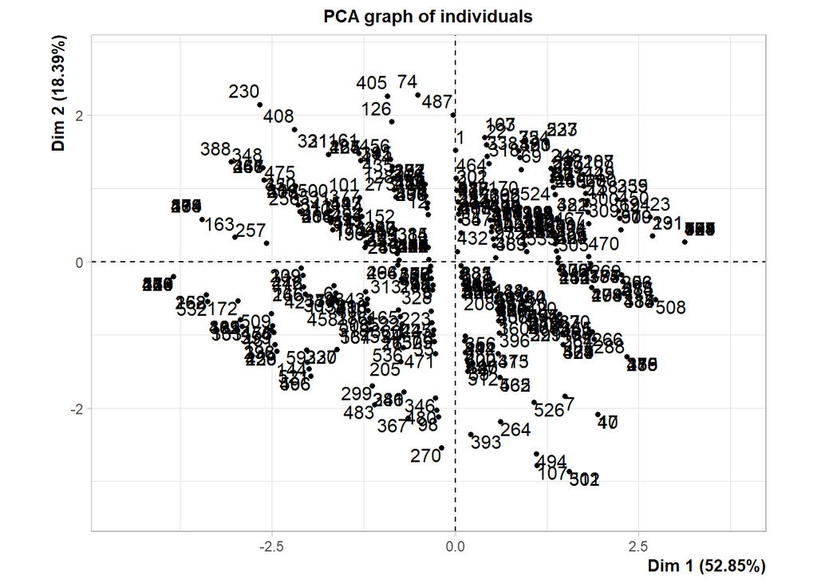

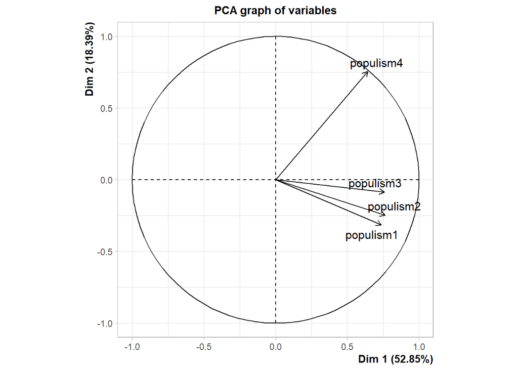

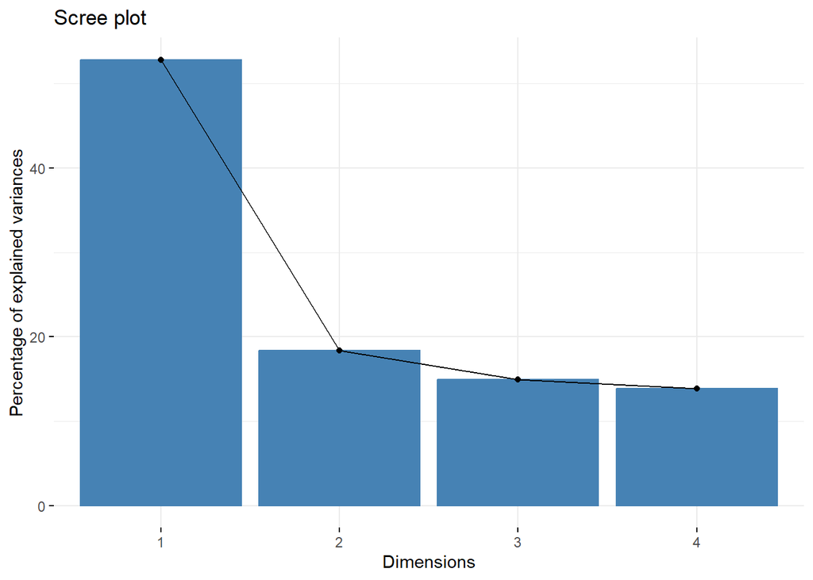

```
##               Dim.1       Dim.2      Dim.3       Dim.4
## populism1 0.7371934 -0.31461897  0.5362986  0.26447031
## populism2 0.7639051 -0.24637491 -0.1010413 -0.58782566
## populism3 0.7581981 -0.08461159 -0.5307142  0.36921395
## populism4 0.6420774  0.75426176  0.1311628 -0.04027559
```

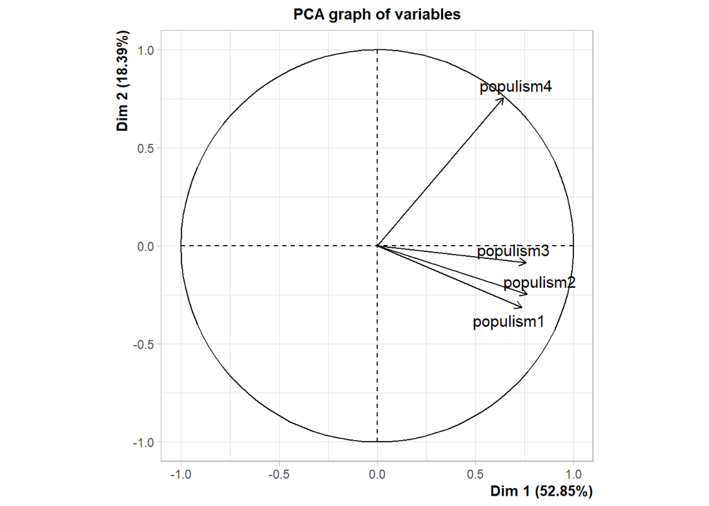

```
##
## Call:
## PCA(X = PCA_pop_data[, 2:5], scale.unit = TRUE, ncp = 2, graph = T)
##
##
## Eigenvalues
##                        Dim.1   Dim.2   Dim.3   Dim.4
## Variance               2.114   0.736   0.597   0.553
## % of var.             52.853  18.394  14.917  13.836
## Cumulative % of var.  52.853  71.247  86.164 100.000
##
## Individuals (the 10 first)
##               Dist    Dim.1    ctr   cos2    Dim.2    ctr   cos2
## 1         |  2.370 |  0.001  0.000  0.000 |  1.518  0.582  0.411 |
## 2         |  2.779 | -2.169  0.413  0.609 |  0.874  0.193  0.099 |
## 3         |  1.754 |  0.587  0.030  0.112 | -0.809  0.165  0.212 |
## 4         |  1.412 |  1.380  0.167  0.956 |  0.149  0.006  0.011 |
## 5         |  3.138 |  3.122  0.857  0.990 |  0.268  0.018  0.007 |
## 6         |  1.892 | -1.659  0.242  0.768 | -0.331  0.028  0.031 |
## 7         |  2.589 |  1.497  0.197  0.334 | -1.838  0.854  0.504 |
## 8         |  1.942 | -0.304  0.008  0.025 | -0.322  0.026  0.027 |
## 9         |  0.839 |  0.031  0.000  0.001 |  0.814  0.168  0.942 |
## 10        |  3.138 |  3.122  0.857  0.990 |  0.268  0.018  0.007 |
##
## Variables
##              Dim.1    ctr   cos2    Dim.2    ctr   cos2
## populism1 |  0.737 25.706  0.543 | -0.315 13.454  0.099 |
## populism2 |  0.764 27.602  0.584 | -0.246  8.250  0.061 |
## populism3 |  0.758 27.191  0.575 | -0.085  0.973  0.007 |
## populism4 |  0.642 19.500  0.412 |  0.754 77.323  0.569 |
```

```
## $Dim.1
##
## Link between the variable and the continuous variables (R-square)
## =================================================================================
##           correlation       p.value
## populism2   0.7639051 4.967018e-104
## populism3   0.7581981 1.265189e-101
## populism1   0.7371934  2.574678e-93
## populism4   0.6420774  7.402881e-64
##
## $Dim.2
##
## Link between the variable and the continuous variables (R-square)
## =================================================================================
##           correlation       p.value
## populism4  0.75426176 5.284648e-100
## populism3 -0.08461159  4.982015e-02
## populism2 -0.24637491  7.003912e-09
## populism1 -0.31461897  7.952034e-14
```

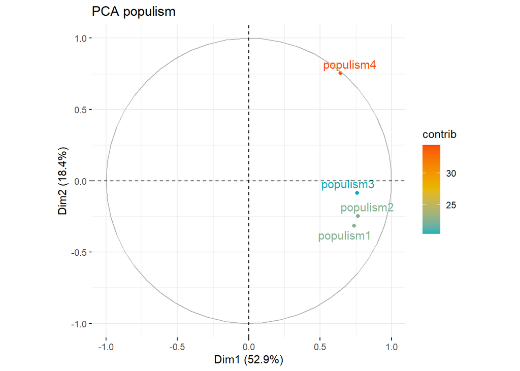

*dimension reduction populism scales 1-4 after PCA*

*final dummy variables populism* create 2 dummy variables for populism a) mean of populism scores items 1-3, but exclude pop 4 -> PCA shows very different b) use principal component 1 as dummy

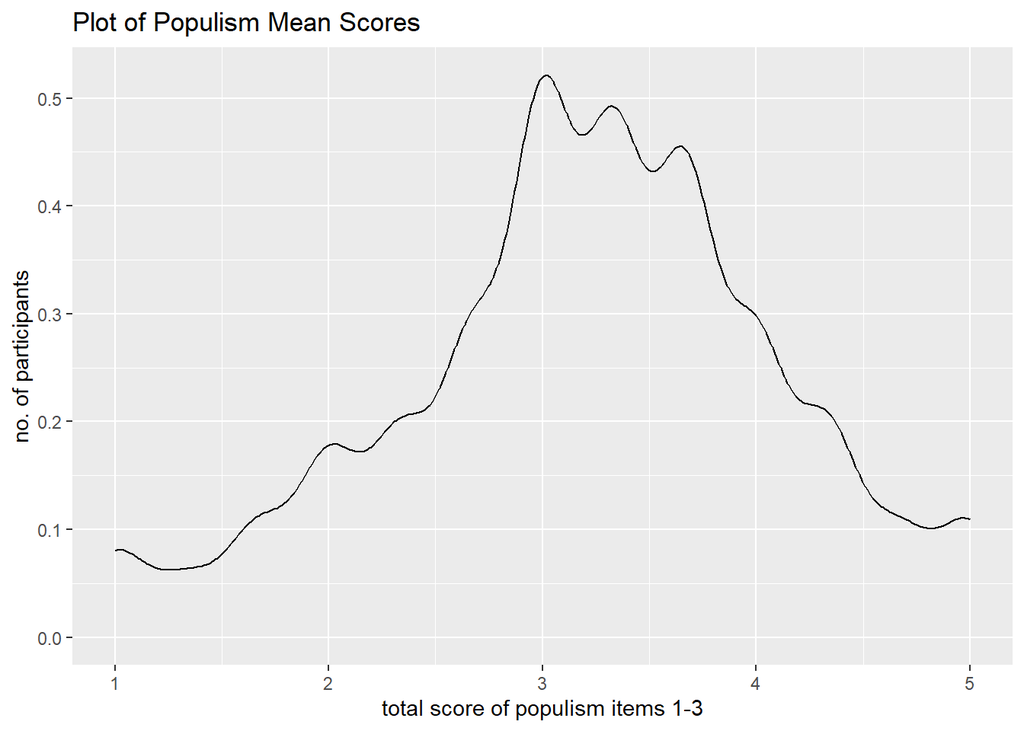

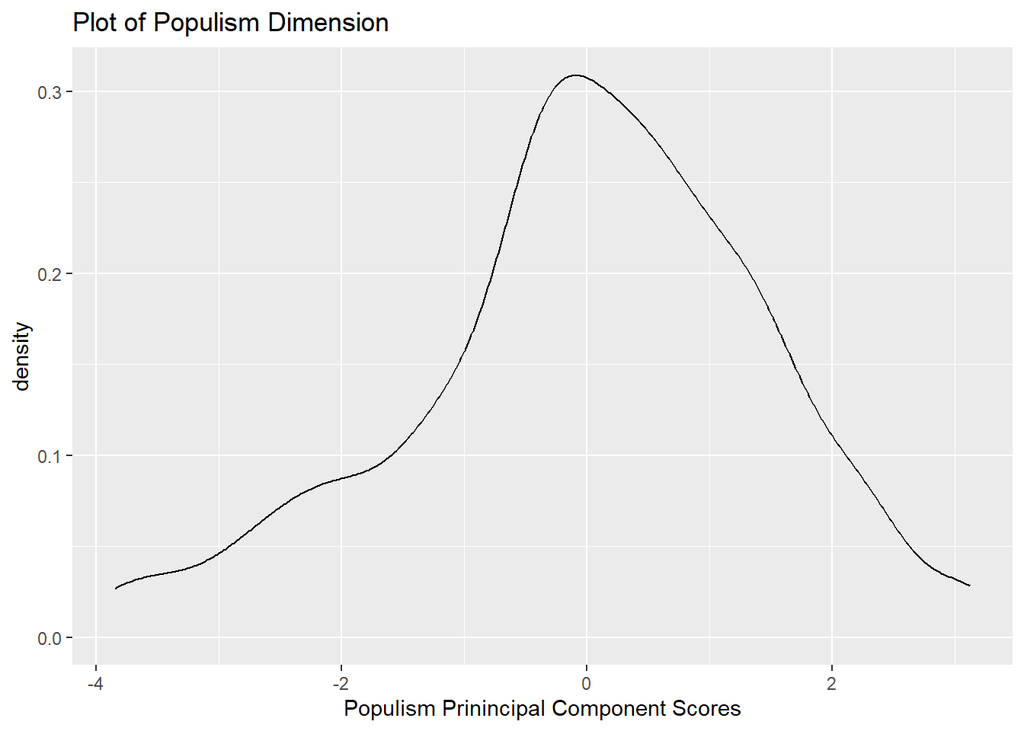

#### 1.7.2. Create subsets - high & low populism

```
## [1] FALSE
```

```
##       0%      25%      50%      75%     100%
## 1.000000 2.666667 3.333333 3.666667 5.000000
```

How many participants in subset high populism?

```
## [1] 287
```

How many participants in subset low populism?

```
## [1] 251
```

### 2.6. Prep SES

#### Create subsets dummy variables education/ training

Create four data sets: high, middle, low as well as middle & low training/ education summary variables

# 2. Descriptives

## 2.1. Leadership stimuli

### Top 6 attributes & consistency

Which attributes most often among top 6 for each leadership group? How consistent is participants’ ranking?

```
## # A tibble: 40 × 6
##    Pre_select_type Pre_select_Attribute rank_counts mean_Rank median_Rank
##    <chr>           <chr>                      <int>     <dbl>       <dbl>
##  1 chariAttribute  begeisternd                  379      4.74           4
##  2 chariAttribute  sympathisch                  377      4.76           4
##  3 chariAttribute  überzeugend                  375      4.77           4
##  4 chariAttribute  selbstbewusst                337      4.93           5
##  5 chariAttribute  authentisch                  335      4.89           5
##  6 chariAttribute  redegewandt                  330      4.68           4
##  7 chariAttribute  ehrlich                      293      5.35           5
##  8 chariAttribute  offen                        251      6.14           6
##  9 chariAttribute  problemlösend                251      5.46           5
## 10 chariAttribute  eloquent                     222      5.65           6
## # ℹ 30 more rows
## # ℹ 1 more variable: RanK_standard_deviation <dbl>
```

### Process of pre-selection of leadership attributes

Average clicks made for selection & average check of allocation variable “count_ click_sequence”: Count of sequences (1 sequence = 2 clicks: 1x selection of attribute + 1x allocation to place) min. 20 variable “count_ check_selection”: Count of calling check-up screen to revise pre-selection (Screen with „Überprüfen Sie Ihre Auswahl…“), value min. 1

```
## # A tibble: 1 × 4
##   mean_clicks sd_click mean_check sd_check
##         <dbl>    <dbl>      <dbl>    <dbl>
## 1        26.0     7.10       1.44     1.61
```

### Practice trials

average no. of practice trials after selection of attributes & average accuracy in last practice trials variable “n_practice”: Count of block no. of pre-selection practice (min: 0-3, max. 7) variable “accuracy_practice_trial”: Accuracy of block no. (max. 1 = 100%)

```
## # A tibble: 1 × 4
##   mean_n_practice sd_practice mean_acc_pract_overall sd_acc_pract_overall
##             <dbl>       <dbl>                  <dbl>                <dbl>
## 1            3.09        1.83                  0.709                0.221
```

```
## # A tibble: 1 × 2
##   mean_accuracy_across_all sd_accuracy_across_all
##                      <dbl>                  <dbl>
## 1                    0.806                  0.205
```

## 2.2. IAT data sets

*No. of different stimuli presented* how many stimuli presented to participants? -> 303! we had: lang. var stimuli: 6 speaker x 2 varieties x 6 stimuli = 72 different stimuli PLUS leadership stimuli: 6 speakers x 2 varieties x 2 leadership cat x 6 stimuli = 144 different stimuli = 216, but since we had individual pre-selection, individuals vary what they picked as stimuli for leadership since not all participants picked the same 6 stimuli for leadership stimuli -> additional variation

```
## [1] 616
```

*No. of participants in different data sets* Ingroup data set

```
## [1] 36
```

Outgroup data set

```
## [1] 538
```

*Participants’ age* age in all data set

```
## # A tibble: 2,452 × 6
## # Groups:   bilendi_id [613]
##    bilendi_id blockno `mean(age)` `sd(age)` `min(age)` `max(age)`
##         <dbl>   <dbl>       <dbl>     <dbl>      <dbl>      <dbl>
##  1    2.63e14       3          67         0         67         67
##  2    2.63e14       4          67         0         67         67
##  3    2.63e14       6          67         0         67         67
##  4    2.63e14       7          67         0         67         67
##  5    2.63e14       3          48         0         48         48
##  6    2.63e14       4          48         0         48         48
##  7    2.63e14       6          48         0         48         48
##  8    2.63e14       7          48         0         48         48
##  9    2.63e14       3          46         0         46         46
## 10    2.63e14       4          46         0         46         46
## # ℹ 2,442 more rows
```

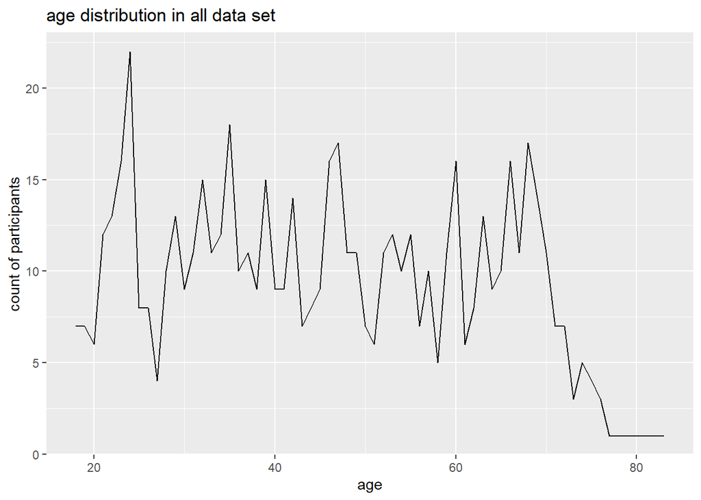

age in outgroup data set

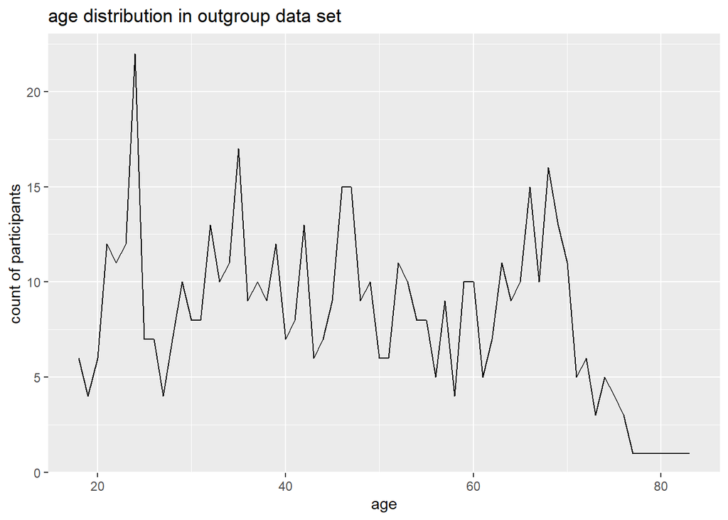

age in ingroup data set

```
## # A tibble: 144 × 6
## # Groups:   bilendi_id [36]
##    bilendi_id blockno `mean(age)` `sd(age)` `min(age)` `max(age)`
##         <dbl>   <dbl>       <dbl>     <dbl>      <dbl>      <dbl>
##  1    2.63e14       3          59         0         59         59
##  2    2.63e14       4          59         0         59         59
##  3    2.63e14       6          59         0         59         59
##  4    2.63e14       7          59         0         59         59
##  5    2.63e14       3          43         0         43         43
##  6    2.63e14       4          43         0         43         43
##  7    2.63e14       6          43         0         43         43
##  8    2.63e14       7          43         0         43         43
##  9    2.63e14       3          60         0         60         60
## 10    2.63e14       4          60         0         60         60
## # ℹ 134 more rows
```

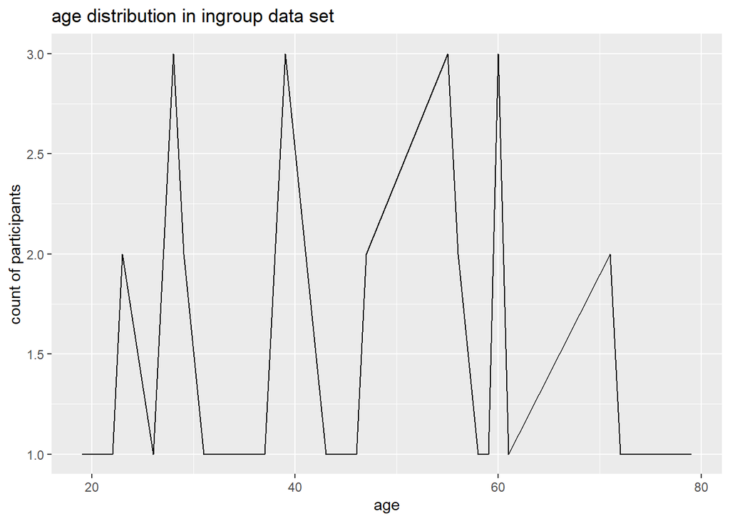

write descriptive age to file

*Participants’ gender* Gender distribution of participants in complete data set

```
## # A tibble: 4 × 2
##   pp_gender `n_distinct(bilendi_id)`
##   <fct>                        <int>
## 1 divers                           1
## 2 female                         334
## 3 male                           279
## 4 <NA>                             2
```

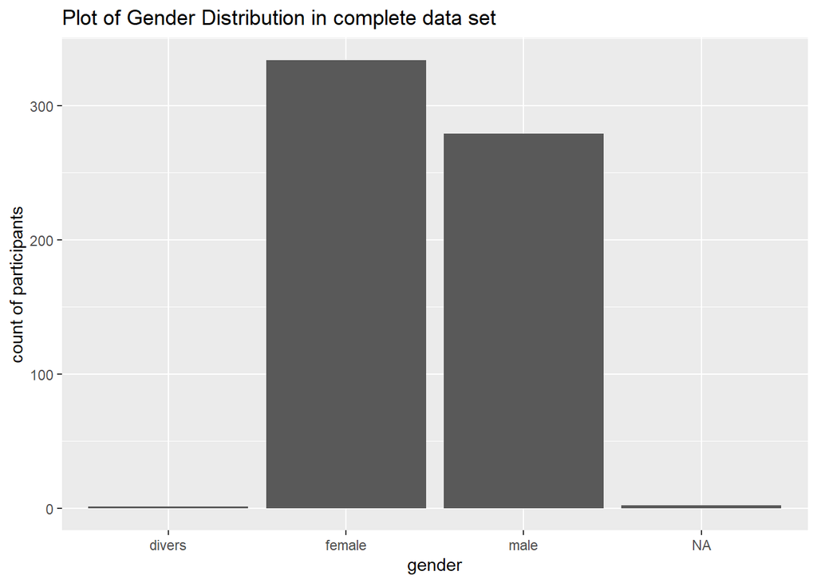

Gender distribution of participants in outgroup data set

```
## # A tibble: 3 × 2
##   pp_gender `n_distinct(bilendi_id)`
##   <fct>                        <int>
## 1 divers                           1
## 2 female                         290
## 3 male                           247
```

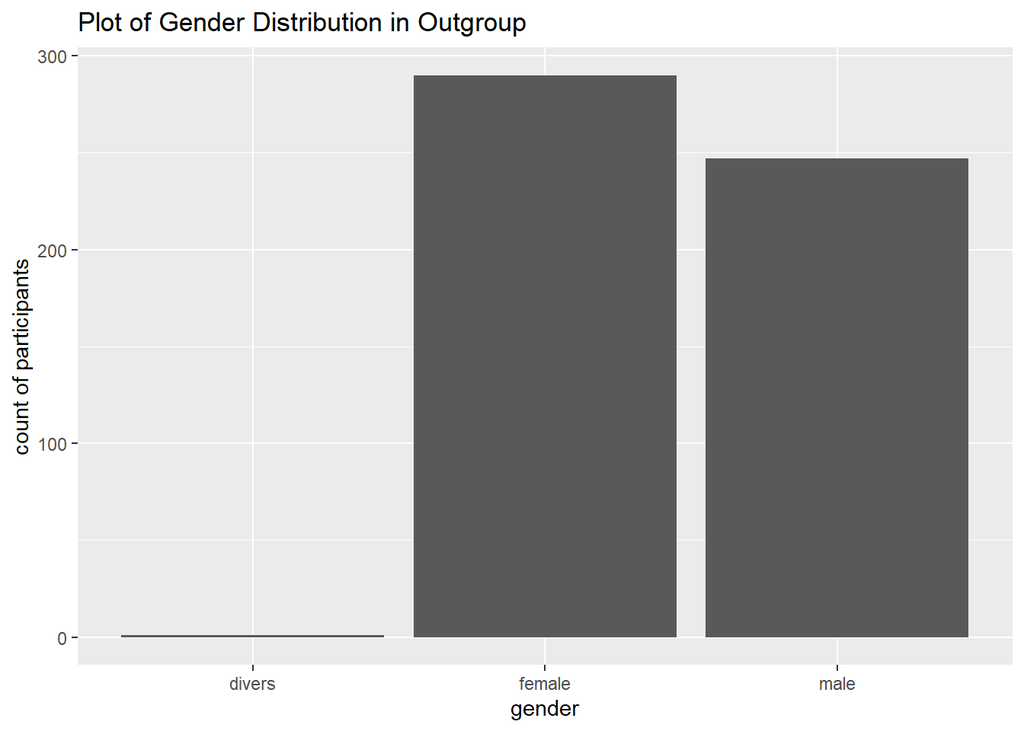

Gender distribution of participants in ingroup data set

```
## # A tibble: 2 × 2
##   pp_gender `n_distinct(bilendi_id)`
##   <fct>                        <int>
## 1 female                          19
## 2 male                            17
```

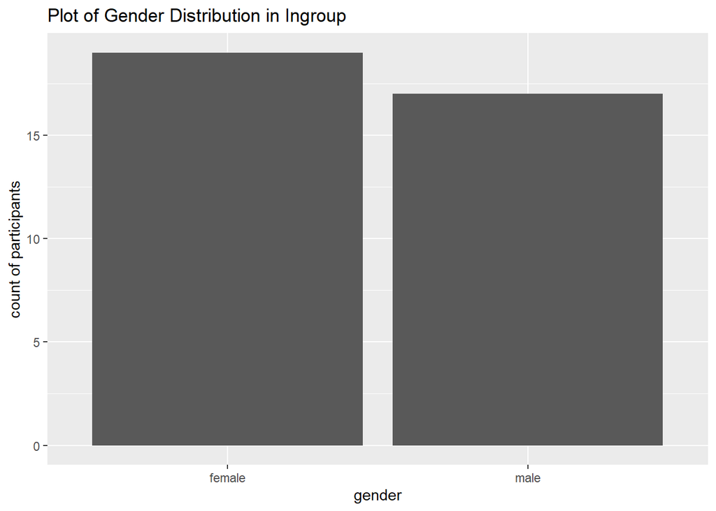

*Participants’ language biography* exposure to language varieties by family member 1 & 2 in outgroup data set

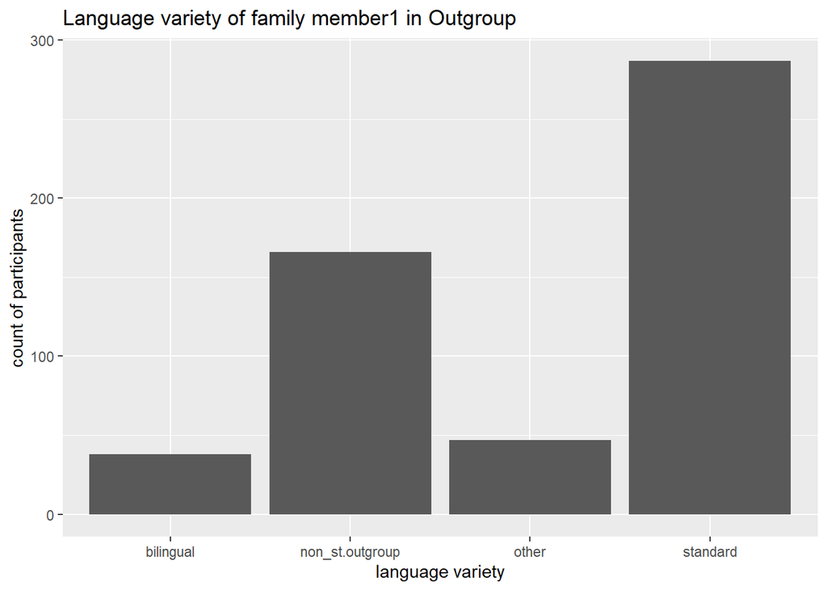

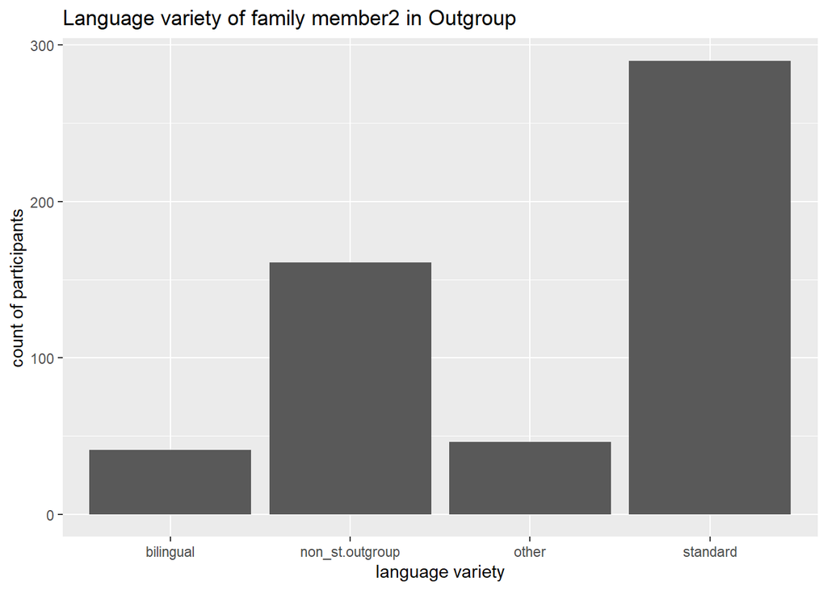

*Participants’ higher education & professional training* In all data set

```
## # A tibble: 4 × 2
##   sum_training count
##   <fct>        <int>
## 1 high           289
## 2 low            128
## 3 middle         196
## 4 <NA>             3
```

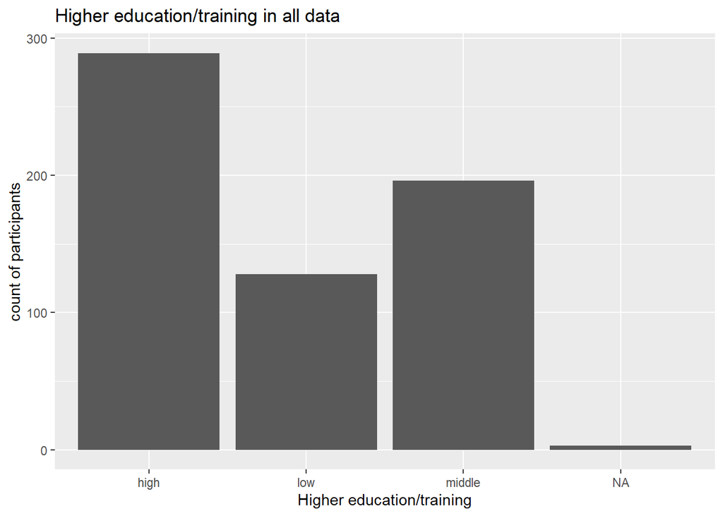

In outgroup data set

```
## # A tibble: 4 × 2
##   sum_training count
##   <fct>        <int>
## 1 high           258
## 2 low            110
## 3 middle         169
## 4 <NA>             1
```

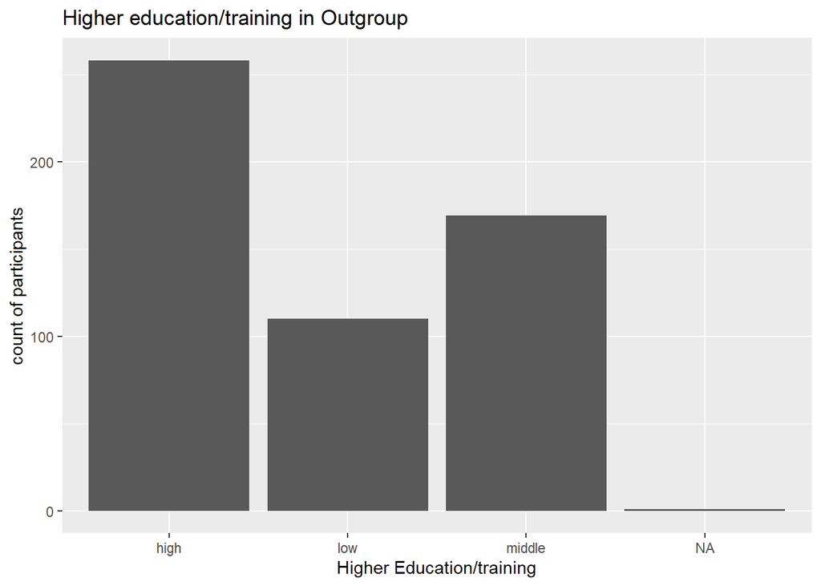

*Participants’ secondary education* In outgroup data set

```
## # A tibble: 5 × 2
##   sum_education   count
##   <fct>           <int>
## 1 high              350
## 2 low                33
## 3 middle            152
## 4 other               1
## 5 still at school     2
```

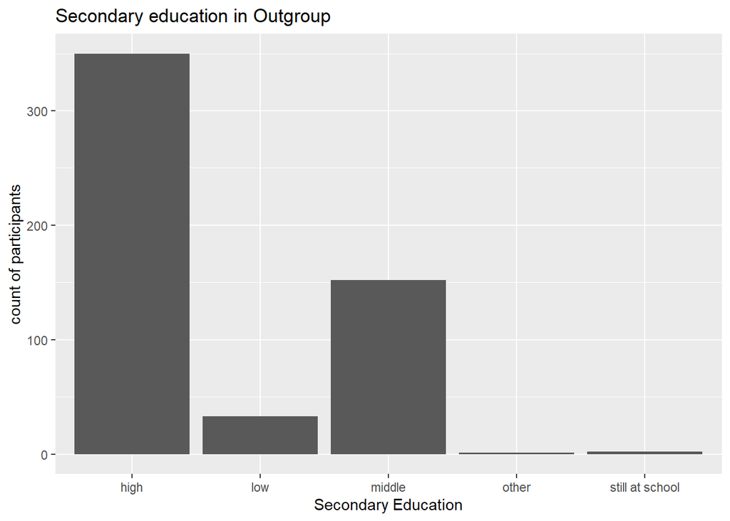

In all data set

```
## # A tibble: 6 × 2
##   sum_education   count
##   <fct>           <int>
## 1 high              390
## 2 low                38
## 3 middle            182
## 4 other               1
## 5 still at school     3
## 6 <NA>                2
```

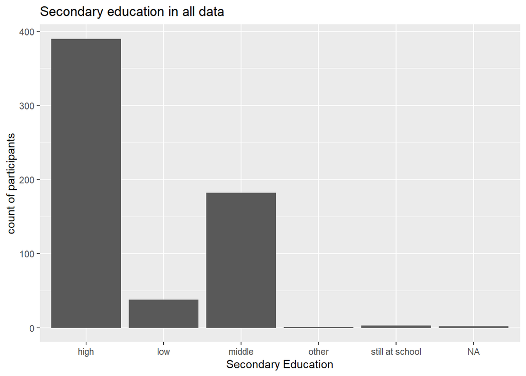

In ingroup data set

```
## # A tibble: 3 × 2
##   sum_education count
##   <fct>         <int>
## 1 high             20
## 2 low               4
## 3 middle           12
```

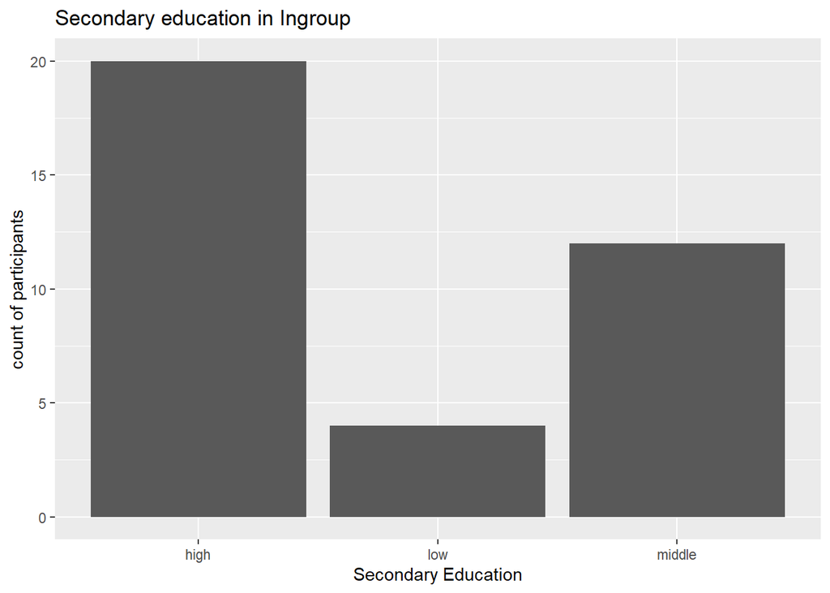

*participants’ political background* **voting behaviour**

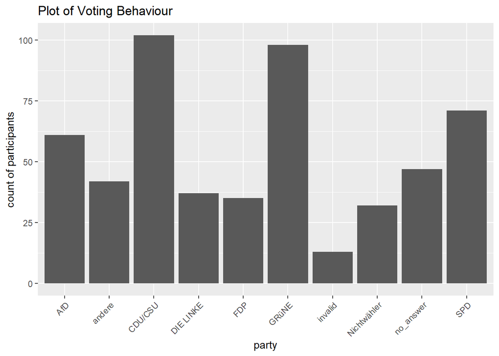

**political ideology**

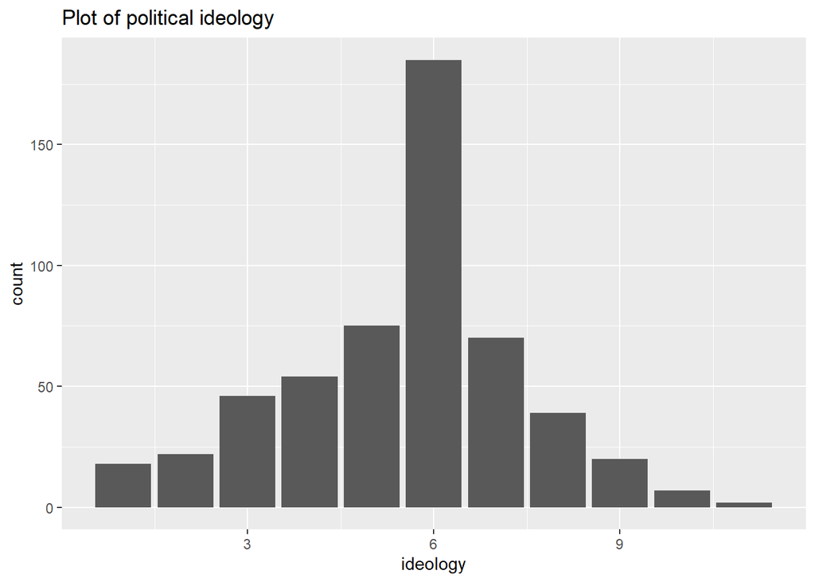

# 3. Analyses of outgroup data set

## 3.1. Correlation matrix

```
##              penal_RTs           age      ideology   populism1   populism2
## penal_RTs  1.000000000  0.1162726545 -0.0491593685 0.008292696 -0.01186507
## age        0.116272655  1.0000000000 -0.0001847734 0.027224360 -0.10717231
## ideology  -0.049159368 -0.0001847734  1.0000000000 0.087012017  0.10185386
## populism1  0.008292696  0.0272243604  0.0870120175 1.000000000  0.42871170
## populism2 -0.011865068 -0.1071723143  0.1018538635 0.428711695  1.00000000
## populism3 -0.023795819 -0.0054521429  0.1603600963 0.399283755  0.43759286
## populism4 -0.034857042 -0.1059965811  0.1165560262 0.296733962  0.31605269
##              populism3   populism4
## penal_RTs -0.023795819 -0.03485704
## age       -0.005452143 -0.10599658
## ideology   0.160360096  0.11655603
## populism1  0.399283755  0.29673396
## populism2  0.437592860  0.31605269
## populism3  1.000000000  0.33863618
## populism4  0.338636181  1.00000000
```

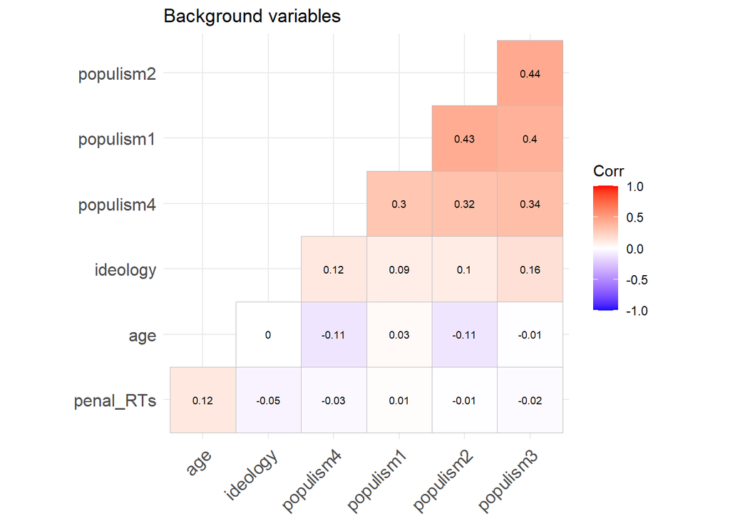

## 3.2. Impact language variety only RQ: Do participants associate standard language variety more with charisma compared the vernacular variety? i.e. Are RTs faster when standard variety is mapped on the same key as charisma compared to when vernacular variety is mapped with charisma independent from study type (which mapping of language variety & charisma participants start with)?

Reaction time experiments need to take into account age related slowing. Two options to address age related slowing in model: 1) use z-scored RTs as DV 2) use age as co-variant

### 3.2.1. GLMs with age standardised RTs as DV

But: all models are singular fits, continue with age as co-variant

### 3.2.2 GLMS - age as covariant

Max. model regarding experimental variables

best fit model: shows 2nd block (standard vernacular-with Charisma vs. vernacular standard-with Charisma) is significantly different

```
## Linear mixed model fit by REML. t-tests use Satterthwaite's method [
## lmerModLmerTest]
## Formula: penal_RTs ~ charisma_lang_var * start_iat + trialcount + stim_cat +
##     age + (charisma_lang_var | bilendi_id) + (start_iat | stimulus_ID)
##    Data: Four_Out
## Control: lmerControl(optimizer = "bobyqa", optCtrl = list(maxfun = 2e+05))
##
## REML criterion at convergence: 153678.3
##
## Scaled residuals:
##     Min      1Q  Median      3Q     Max
## -6.2899 -0.6202 -0.1215  0.5483 13.5274
##
## Random effects:
##  Groups      Name                              Variance Std.Dev. Corr
##  bilendi_id  (Intercept)                       0.302931 0.55039
##              charisma_lang_varvernacular       0.207010 0.45498  -0.24
##  stimulus_ID (Intercept)                       0.016566 0.12871
##              start_iatvernacular-with Charisma 0.001884 0.04341  -0.35
##  Residual                                      0.598259 0.77347
## Number of obs: 64365, groups:  bilendi_id, 537; stimulus_ID, 303
##
## Fixed effects:
##                                                                 Estimate
## (Intercept)                                                    4.679e-01
## charisma_lang_varvernacular                                    7.583e-01
## start_iatvernacular-with Charisma                              5.910e-01
## trialcount                                                    -7.813e-03
## stim_catleadership                                             1.864e-01
## age                                                            1.048e-01
## charisma_lang_varvernacular:start_iatvernacular-with Charisma -1.326e+00
##                                                               Std. Error
## (Intercept)                                                    4.059e-02
## charisma_lang_varvernacular                                    3.422e-02
## start_iatvernacular-with Charisma                              5.106e-02
## trialcount                                                     1.763e-04
## stim_catleadership                                             1.761e-02
## age                                                            2.327e-02
## charisma_lang_varvernacular:start_iatvernacular-with Charisma  5.205e-02
##                                                                       df
```

[output cut: 19 more lines]

```
## trialcount                                                    ***
## stim_catleadership                                            ***
## age                                                           ***
## charisma_lang_varvernacular:start_iatvernacular-with Charisma ***
## ---
## Signif. codes:  0 '***' 0.001 '**' 0.01 '*' 0.05 '.' 0.1 ' ' 1
##
## Correlation of Fixed Effects:
##             (Intr) chrs__ str_-C trlcnt stm_ct age
## chrsm_lng_v -0.066
## strt_tvrn-C -0.521  0.309
## trialcount  -0.306 -0.464 -0.311
## stm_ctldrsh -0.319  0.000  0.004  0.000
## age         -0.014  0.000  0.020  0.000  0.001
## chrsm__:_-C -0.050 -0.799 -0.391  0.610  0.000  0.000
```

```
## Type III Analysis of Variance Table with Satterthwaite's method
##                              Sum Sq Mean Sq NumDF DenDF   F value    Pr(>F)
## charisma_lang_var             12.78   12.78     1   535   21.3625 4.771e-06 ***
## start_iat                      1.38    1.38     1   536    2.3062    0.1294
## trialcount                  1174.60 1174.60     1 63035 1963.3673 < 2.2e-16 ***
## stim_cat                      66.98   66.98     1   263  111.9604 < 2.2e-16 ***
## age                           12.13   12.13     1   534   20.2791 8.225e-06 ***
## charisma_lang_var:start_iat  388.19  388.19     1  1350  648.8659 < 2.2e-16 ***
## ---
## Signif. codes:  0 '***' 0.001 '**' 0.01 '*' 0.05 '.' 0.1 ' ' 1
```

[output not shown]

[output not shown]

```
## $emmeans
##  charisma_lang_var start_iat                emmean     SE  df asymp.LCL
##  standard          standard-with Charisma   -0.341 0.0375 Inf    -0.415
##  vernacular        standard-with Charisma    0.417 0.0418 Inf     0.335
##  standard          vernacular-with Charisma  0.250 0.0348 Inf     0.182
##  vernacular        vernacular-with Charisma -0.318 0.0387 Inf    -0.394
##  asymp.UCL
##     -0.268
##      0.499
##      0.318
##     -0.242
##
## Results are averaged over the levels of: stim_cat
## Degrees-of-freedom method: asymptotic
## Confidence level used: 0.95
##
## $contrasts
##  contrast
##  (standard standard-with Charisma) - (vernacular standard-with Charisma)
##  (standard standard-with Charisma) - (standard vernacular-with Charisma)
##  (standard standard-with Charisma) - (vernacular vernacular-with Charisma)
##  (vernacular standard-with Charisma) - (standard vernacular-with Charisma)
##  (vernacular standard-with Charisma) - (vernacular vernacular-with Charisma)
##  (standard vernacular-with Charisma) - (vernacular vernacular-with Charisma)
##  estimate     SE  df z.ratio p.value
##   -0.7583 0.0342 Inf -22.159  <.0001
##   -0.5910 0.0511 Inf -11.574  <.0001
##   -0.0234 0.0514 Inf  -0.454  0.9688
##    0.1673 0.0519 Inf   3.222  0.0070
##    0.7350 0.0569 Inf  12.910  <.0001
##    0.5676 0.0322 Inf  17.646  <.0001
##
## Results are averaged over the levels of: stim_cat
## Degrees-of-freedom method: asymptotic
## P value adjustment: tukey method for comparing a family of 4 estimates
```

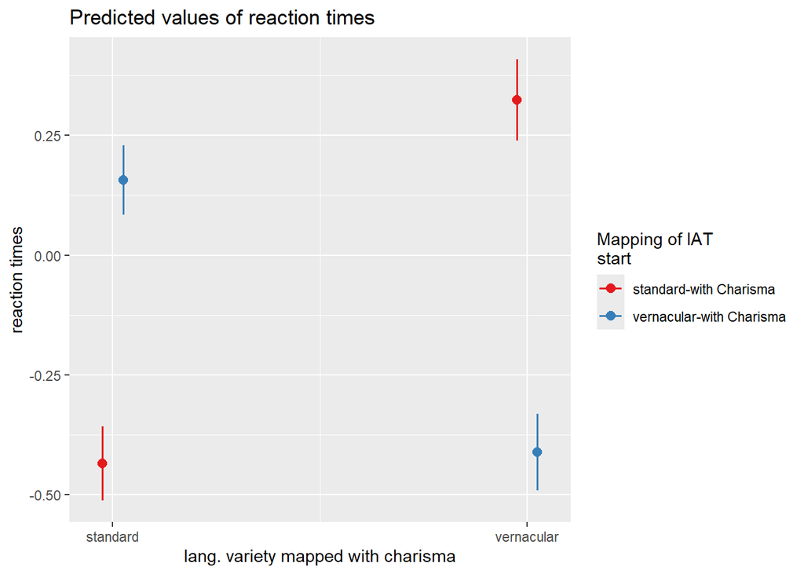

```
## We fitted a linear mixed model (estimated using REML and BOBYQA optimizer) to
## predict penal_RTs with charisma_lang_var, start_iat, trialcount, stim_cat and
## age (formula: penal_RTs ~ charisma_lang_var * start_iat + trialcount + stim_cat
## + age). The model included charisma_lang_var as random effects (formula:
## list(~charisma_lang_var | bilendi_id, ~start_iat | stimulus_ID)). The model's
## total explanatory power is substantial (conditional R2 = 0.40) and the part
## related to the fixed effects alone (marginal R2) is of 0.04. The model's
## intercept, corresponding to charisma_lang_var = standard, start_iat =
## standard-with Charisma, trialcount = 0, stim_cat = lang.var and age = 0, is at
## 0.47 (95% CI [0.39, 0.55], t(64351) = 11.53, p < .001). Within this model:
##
##   - The effect of charisma lang var [vernacular] is statistically significant and
## positive (beta = 0.76, 95% CI [0.69, 0.83], t(64351) = 22.16, p < .001; Std.
## beta = 0.76, 95% CI [0.69, 0.83])
##   - The effect of start iat [vernacular-with Charisma] is statistically
## significant and positive (beta = 0.59, 95% CI [0.49, 0.69], t(64351) = 11.57, p
## < .001; Std. beta = 0.59, 95% CI [0.49, 0.69])
##   - The effect of trialcount is statistically significant and negative (beta =
## -7.81e-03, 95% CI [-8.16e-03, -7.47e-03], t(64351) = -44.31, p < .001; Std.
## beta = -0.38, 95% CI [-0.39, -0.36])
##   - The effect of stim cat [leadership] is statistically significant and positive
## (beta = 0.19, 95% CI [0.15, 0.22], t(64351) = 10.58, p < .001; Std. beta =
## 0.19, 95% CI [0.15, 0.22])
##   - The effect of age is statistically significant and positive (beta = 0.10, 95%
## CI [0.06, 0.15], t(64351) = 4.50, p < .001; Std. beta = 0.10, 95% CI [0.06,
## 0.15])
##   - The effect of charisma lang var [vernacular] × start iat [vernacular-with
## Charisma] is statistically significant and negative (beta = -1.33, 95% CI
## [-1.43, -1.22], t(64351) = -25.47, p < .001; Std. beta = -1.33, 95% CI [-1.43,
## -1.22])
##
## Standardized parameters were obtained by fitting the model on a standardized
## version of the dataset. 95% Confidence Intervals (CIs) and p-values were
## computed using a Wald t-distribution approximation.
```

change reference level to vernacular

```
## Linear mixed model fit by REML. t-tests use Satterthwaite's method [
## lmerModLmerTest]
## Formula: penal_RTs ~ charisma_lang_var * start_iat + trialcount + age +
##     leadership_lang_var + stim_cat + (charisma_lang_var | bilendi_id) +
##     (start_iat | stimulus_ID)
##    Data: Four_Out
## Control: lmerControl(optimizer = "bobyqa", optCtrl = list(maxfun = 2e+05))
##
## REML criterion at convergence: 153678.7
##
## Scaled residuals:
##     Min      1Q  Median      3Q     Max
## -6.2906 -0.6201 -0.1212  0.5483 13.5283
##
## Random effects:
##  Groups      Name                            Variance Std.Dev. Corr
##  bilendi_id  (Intercept)                     0.388383 0.62320
##              charisma_lang_varstandard       0.207010 0.45498  -0.52
##  stimulus_ID (Intercept)                     0.014572 0.12072
##              start_iatstandard-with Charisma 0.001883 0.04339  0.01
##  Residual                                    0.598255 0.77347
## Number of obs: 64365, groups:  bilendi_id, 537; stimulus_ID, 303
##
## Fixed effects:
##                                                             Estimate Std. Error
## (Intercept)                                                4.526e-01  4.614e-02
## charisma_lang_varstandard                                  5.676e-01  3.217e-02
## start_iatstandard-with Charisma                            7.331e-01  5.700e-02
## trialcount                                                -7.813e-03  1.763e-04
## age                                                        1.059e-01  2.322e-02
## leadership_lang_var2                                       9.267e-02  4.718e-02
## stim_catleadership                                         1.862e-01  1.763e-02
## charisma_lang_varstandard:start_iatstandard-with Charisma -1.326e+00  5.205e-02
##                                                                   df t value
## (Intercept)                                                8.229e+02   9.808
## charisma_lang_varstandard                                  9.328e+02  17.646
## start_iatstandard-with Charisma                            6.242e+02  12.860
## trialcount                                                 6.304e+04 -44.310
## age                                                        5.330e+02   4.558
## leadership_lang_var2                                       5.429e+02   1.964
```

[output cut: 8 more lines]

```
## leadership_lang_var2                                          0.05 .
## stim_catleadership                                         < 2e-16 ***
## charisma_lang_varstandard:start_iatstandard-with Charisma  < 2e-16 ***
## ---
## Signif. codes:  0 '***' 0.001 '**' 0.01 '*' 0.05 '.' 0.1 ' ' 1
##
## Correlation of Fixed Effects:
##             (Intr) chrs__ str_-C trlcnt age    ldr__2 stm_ct
## chrsm_lng_v -0.233
## strt_tstn-C -0.439  0.434
## trialcount  -0.269 -0.493 -0.278
## age         -0.004  0.000 -0.019  0.000
## ldrshp_ln_2 -0.426  0.000 -0.017  0.000  0.033
## stm_ctldrsh -0.275  0.000 -0.004  0.000  0.000 -0.004
## chrsm__:_-C  0.062 -0.768 -0.568  0.610  0.000  0.000  0.000
```

## 3.3. Language variety plus foci

### 3.3.1. Age

explore age related slowing: present in general but not in interaction with study type variable “start_iat” & “charisma_lang_var”.

```
## fixed-effect model matrix is rank deficient so dropping 1 column / coefficient
## fixed-effect model matrix is rank deficient so dropping 1 column / coefficient
```

```
## Linear mixed model fit by REML. t-tests use Satterthwaite's method [
## lmerModLmerTest]
## Formula: penal_RTs ~ charisma_lang_var:start_iat + charisma_lang_var:age +
##     trialcount + leadership_lang_var + speaker_gender + stim_cat +
##     (charisma_lang_var | bilendi_id) + (start_iat | stimulus_ID)
##    Data: Four_Out
## Control: lmerControl(optimizer = "bobyqa", optCtrl = list(maxfun = 2e+05))
##
## REML criterion at convergence: 153677.9
##
## Scaled residuals:
##     Min      1Q  Median      3Q     Max
## -6.2878 -0.6201 -0.1213  0.5483 13.5242
##
## Random effects:
##  Groups      Name                              Variance Std.Dev. Corr
##  bilendi_id  (Intercept)                       0.29951  0.54728
##              charisma_lang_varvernacular       0.20411  0.45179  -0.24
##  stimulus_ID (Intercept)                       0.01657  0.12871
##              start_iatvernacular-with Charisma 0.00189  0.04347  -0.35
##  Residual                                      0.59825  0.77347
## Number of obs: 64365, groups:  bilendi_id, 537; stimulus_ID, 303
##
## Fixed effects:
##                                                               Estimate
## (Intercept)                                                  4.098e-01
## trialcount                                                  -7.813e-03
## leadership_lang_var2                                         9.253e-02
## speaker_gendermale                                           8.599e-02
## stim_catleadership                                           1.860e-01
## charisma_lang_varstandard:start_iatstandard-with Charisma   -2.516e-02
## charisma_lang_varvernacular:start_iatstandard-with Charisma  7.318e-01
## charisma_lang_varstandard:start_iatvernacular-with Charisma  5.664e-01
## charisma_lang_varstandard:age                                9.154e-02
## charisma_lang_varvernacular:age                              1.490e-01
##                                                             Std. Error
## (Intercept)                                                  5.225e-02
## trialcount                                                   1.763e-04
## leadership_lang_var2                                         4.709e-02
## speaker_gendermale                                           4.869e-02
```

[output cut: 49 more lines]

```
## chrsm_lng_vrstndrd:strt_tv-C  0.325                        0.432
## chrsm_lng_vrs:               -0.019                       -0.015
## chrsm_lng_vrv:               -0.019                       -0.021
##                              chrsm_lng_vrstndrd:strt_tv-C chrsm_lng_vrs:
## trialcount
## ldrshp_ln_2
## spkr_gndrml
## stm_ctldrsh
## chrsm_lng_vrstndrd:strt_ts-C
## chrsm_lng_vrv:_-C
## chrsm_lng_vrstndrd:strt_tv-C
## chrsm_lng_vrs:                0.004
## chrsm_lng_vrv:               -0.007                        0.689
## fit warnings:
## fixed-effect model matrix is rank deficient so dropping 1 column / coefficient
```

```
## Type III Analysis of Variance Table with Satterthwaite's method
##                              Sum Sq Mean Sq NumDF DenDF   F value    Pr(>F)
## trialcount                  1174.58 1174.58     1 63036 1963.3449 < 2.2e-16 ***
## leadership_lang_var            2.31    2.31     1   542    3.8606   0.04994 *
## speaker_gender                 1.87    1.87     1   626    3.1193   0.07786 .
## stim_cat                      66.69   66.69     1   263  111.4762 < 2.2e-16 ***
## charisma_lang_var:start_iat  397.30  132.43     3   735  221.3647 < 2.2e-16 ***
## charisma_lang_var:age         17.96    8.98     2   533   15.0113 4.547e-07 ***
## ---
## Signif. codes:  0 '***' 0.001 '**' 0.01 '*' 0.05 '.' 0.1 ' ' 1
```

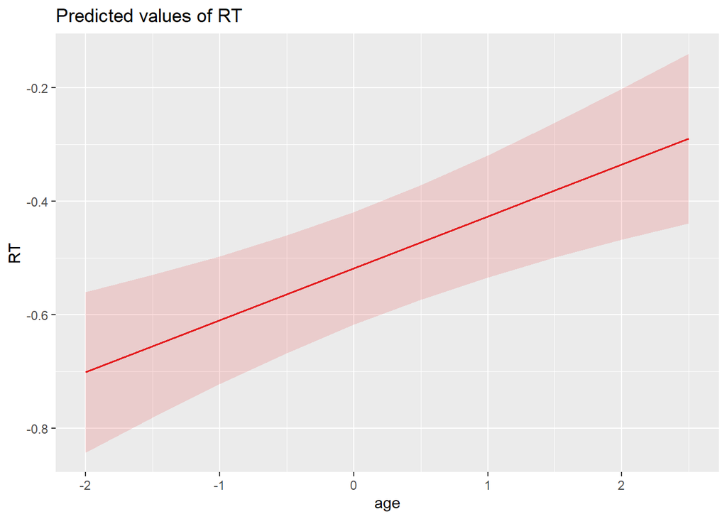

```
## Note: D.f. calculations have been disabled because the number of observations exceeds 3000.
## To enable adjustments, add the argument 'pbkrtest.limit = 64365' (or larger)
## [or, globally, 'set emm_options(pbkrtest.limit = 64365)' or larger];
## but be warned that this may result in large computation time and memory use.
```

```
## Note: D.f. calculations have been disabled because the number of observations exceeds 3000.
## To enable adjustments, add the argument 'lmerTest.limit = 64365' (or larger)
## [or, globally, 'set emm_options(lmerTest.limit = 64365)' or larger];
## but be warned that this may result in large computation time and memory use.
```

```
## NOTE: A nesting structure was detected in the fitted model:
##     start_iat %in% charisma_lang_var
```

```
## $emmeans
##  start_iat                charisma_lang_var emmean     SE  df asymp.LCL
##  standard-with Charisma   standard          -0.335 0.0374 Inf    -0.409
##  vernacular-with Charisma standard           0.256 0.0348 Inf     0.188
##  standard-with Charisma   vernacular         0.422 0.0418 Inf     0.340
##  vernacular-with Charisma vernacular        -0.310 0.0388 Inf    -0.386
##  asymp.UCL
##     -0.262
##      0.324
##      0.503
##     -0.234
##
## Results are averaged over the levels of: leadership_lang_var, speaker_gender, stim_cat
## Degrees-of-freedom method: asymptotic
## Confidence level used: 0.95
##
## $contrasts
##  contrast
##  (standard-with Charisma standard) - (vernacular-with Charisma standard)
##  (standard-with Charisma standard) - (standard-with Charisma vernacular)
##  (standard-with Charisma standard) - (vernacular-with Charisma vernacular)
##  (vernacular-with Charisma standard) - (standard-with Charisma vernacular)
##  (vernacular-with Charisma standard) - (vernacular-with Charisma vernacular)
##  (standard-with Charisma vernacular) - (vernacular-with Charisma vernacular)
##  estimate     SE  df z.ratio p.value
##   -0.5916 0.0508 Inf -11.640  <.0001
##   -0.7570 0.0341 Inf -22.228  <.0001
##   -0.0252 0.0512 Inf  -0.491  0.9611
##   -0.1654 0.0517 Inf  -3.197  0.0076
##    0.5664 0.0320 Inf  17.692  <.0001
##    0.7318 0.0568 Inf  12.891  <.0001
##
## Results are averaged over the levels of: leadership_lang_var, speaker_gender, stim_cat
## Degrees-of-freedom method: asymptotic
## P value adjustment: tukey method for comparing a family of 4 estimates
```

```
## Note: D.f. calculations have been disabled because the number of observations exceeds 3000.
## To enable adjustments, add the argument 'pbkrtest.limit = 64365' (or larger)
## [or, globally, 'set emm_options(pbkrtest.limit = 64365)' or larger];
## but be warned that this may result in large computation time and memory use.
```

```
## Note: D.f. calculations have been disabled because the number of observations exceeds 3000.
## To enable adjustments, add the argument 'lmerTest.limit = 64365' (or larger)
## [or, globally, 'set emm_options(lmerTest.limit = 64365)' or larger];
## but be warned that this may result in large computation time and memory use.
```

```
## NOTE: A nesting structure was detected in the fitted model:
##     start_iat %in% charisma_lang_var
```

```
##  charisma_lang_var age.trend     SE  df asymp.LCL asymp.UCL
##  standard             0.0915 0.0241 Inf    0.0443     0.139
##  vernacular           0.1490 0.0272 Inf    0.0957     0.202
##
## Results are averaged over the levels of: start_iat, leadership_lang_var, speaker_gender, stim_cat
## Degrees-of-freedom method: asymptotic
## Confidence level used: 0.95
```

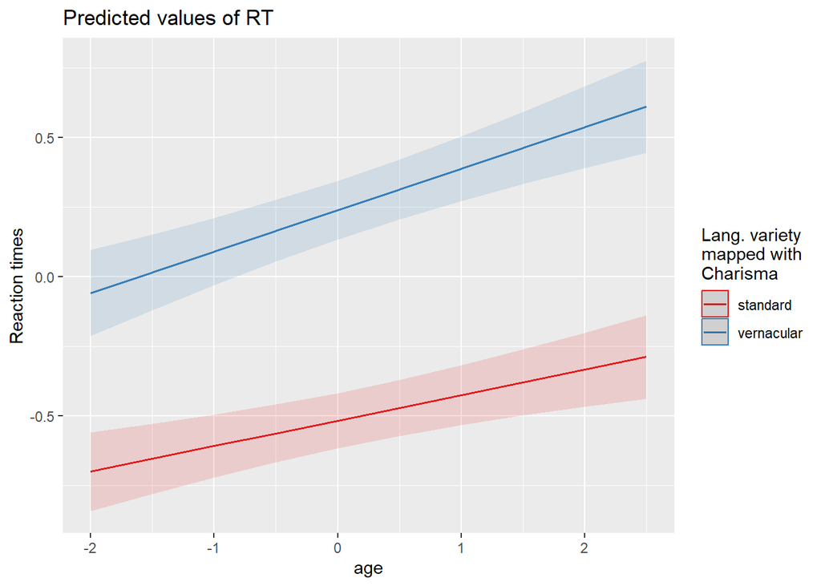

### 3.3.2 Family language

```
## Linear mixed model fit by REML. t-tests use Satterthwaite's method [
## lmerModLmerTest]
## Formula:
## penal_RTs ~ charisma_lang_var * start_iat * family_member1_cat.response +
##     trialcount + age + leadership_lang_var + stim_cat + (charisma_lang_var |
##     bilendi_id) + (start_iat | stimulus_ID)
##    Data: Four_Out
## Control: lmerControl(optimizer = "bobyqa", optCtrl = list(maxfun = 2e+05))
##
## REML criterion at convergence: 153701.1
##
## Scaled residuals:
##     Min      1Q  Median      3Q     Max
## -6.2944 -0.6203 -0.1213  0.5485 13.5313
##
## Random effects:
##  Groups      Name                              Variance Std.Dev. Corr
##  bilendi_id  (Intercept)                       0.298845 0.54667
##              charisma_lang_varvernacular       0.208831 0.45698  -0.24
##  stimulus_ID (Intercept)                       0.016584 0.12878
##              start_iatvernacular-with Charisma 0.001885 0.04342  -0.35
##  Residual                                      0.598255 0.77347
## Number of obs: 64365, groups:  bilendi_id, 537; stimulus_ID, 303
##
## Fixed effects:
##                                                                                                            Estimate
## (Intercept)                                                                                               5.106e-01
## charisma_lang_varvernacular                                                                               7.725e-01
## start_iatvernacular-with Charisma                                                                         4.989e-01
## family_member1_cat.responsebilingual                                                                      2.135e-02
## family_member1_cat.responsenon_st.outgroup                                                               -1.650e-01
## family_member1_cat.responseother                                                                         -2.570e-01
## trialcount                                                                                               -7.813e-03
## age                                                                                                       1.044e-01
## leadership_lang_var2                                                                                      8.332e-02
## stim_catleadership                                                                                        1.862e-01
## charisma_lang_varvernacular:start_iatvernacular-with Charisma                                            -1.327e+00
## charisma_lang_varvernacular:family_member1_cat.responsebilingual                                         -1.156e-01
## charisma_lang_varvernacular:family_member1_cat.responsenon_st.outgroup                                   -1.050e-03
## charisma_lang_varvernacular:family_member1_cat.responseother                                             -8.194e-02
```

[output cut: 98 more lines]

```
## age                                                                                                      ***
## leadership_lang_var2                                                                                     .
## stim_catleadership                                                                                       ***
## charisma_lang_varvernacular:start_iatvernacular-with Charisma                                            ***
## charisma_lang_varvernacular:family_member1_cat.responsebilingual
## charisma_lang_varvernacular:family_member1_cat.responsenon_st.outgroup
## charisma_lang_varvernacular:family_member1_cat.responseother
## start_iatvernacular-with Charisma:family_member1_cat.responsebilingual
## start_iatvernacular-with Charisma:family_member1_cat.responsenon_st.outgroup
## start_iatvernacular-with Charisma:family_member1_cat.responseother
## charisma_lang_varvernacular:start_iatvernacular-with Charisma:family_member1_cat.responsebilingual
## charisma_lang_varvernacular:start_iatvernacular-with Charisma:family_member1_cat.responsenon_st.outgroup
## charisma_lang_varvernacular:start_iatvernacular-with Charisma:family_member1_cat.responseother
## ---
## Signif. codes:  0 '***' 0.001 '**' 0.01 '*' 0.05 '.' 0.1 ' ' 1
```

```
##
## Correlation matrix not shown by default, as p = 20 > 12.
## Use print(x, correlation=TRUE)  or
##     vcov(x)        if you need it
```

```
## Type III Analysis of Variance Table with Satterthwaite's method
##                                                          Sum Sq Mean Sq NumDF
## charisma_lang_var                                          3.95    3.95     1
## start_iat                                                  0.02    0.02     1
## family_member1_cat.response                                3.17    1.06     3
## trialcount                                              1174.59 1174.59     1
## age                                                       11.63   11.63     1
## leadership_lang_var                                        1.87    1.87     1
## stim_cat                                                  66.77   66.77     1
## charisma_lang_var:start_iat                              227.11  227.11     1
## charisma_lang_var:family_member1_cat.response              0.62    0.21     3
## start_iat:family_member1_cat.response                      2.66    0.89     3
## charisma_lang_var:start_iat:family_member1_cat.response    0.51    0.17     3
##                                                         DenDF   F value
## charisma_lang_var                                         529    6.6044
## start_iat                                                 528    0.0288
## family_member1_cat.response                               526    1.7642
## trialcount                                              63036 1963.3561
## age                                                       527   19.4416
## leadership_lang_var                                       537    3.1213
## stim_cat                                                  263  111.6127
## charisma_lang_var:start_iat                               886  379.6221
## charisma_lang_var:family_member1_cat.response             529    0.3453
## start_iat:family_member1_cat.response                     526    1.4844
## charisma_lang_var:start_iat:family_member1_cat.response   529    0.2869
##                                                            Pr(>F)
## charisma_lang_var                                         0.01045 *
## start_iat                                                 0.86523
## family_member1_cat.response                               0.15299
## trialcount                                              < 2.2e-16 ***
## age                                                     1.258e-05 ***
## leadership_lang_var                                       0.07784 .
## stim_cat                                                < 2.2e-16 ***
## charisma_lang_var:start_iat                             < 2.2e-16 ***
## charisma_lang_var:family_member1_cat.response             0.79255
## start_iat:family_member1_cat.response                     0.21782
## charisma_lang_var:start_iat:family_member1_cat.response   0.83491
## ---
## Signif. codes:  0 '***' 0.001 '**' 0.01 '*' 0.05 '.' 0.1 ' ' 1
```

```
## Linear mixed model fit by REML. t-tests use Satterthwaite's method [
## lmerModLmerTest]
## Formula:
## penal_RTs ~ charisma_lang_var * start_iat * family_member2_cat.response +
##     trialcount + age + leadership_lang_var + stim_cat + (charisma_lang_var |
##     bilendi_id) + (start_iat | stimulus_ID)
##    Data: Four_Out
## Control: lmerControl(optimizer = "bobyqa", optCtrl = list(maxfun = 2e+05))
##
## REML criterion at convergence: 153701.1
##
## Scaled residuals:
##     Min      1Q  Median      3Q     Max
## -6.2940 -0.6203 -0.1212  0.5484 13.5317
##
## Random effects:
##  Groups      Name                              Variance Std.Dev. Corr
##  bilendi_id  (Intercept)                       0.298257 0.54613
##              charisma_lang_varvernacular       0.208876 0.45703  -0.24
##  stimulus_ID (Intercept)                       0.016585 0.12878
##              start_iatvernacular-with Charisma 0.001885 0.04342  -0.35
##  Residual                                      0.598255 0.77347
## Number of obs: 64365, groups:  bilendi_id, 537; stimulus_ID, 303
##
## Fixed effects:
##                                                                                                            Estimate
## (Intercept)                                                                                               5.031e-01
## charisma_lang_varvernacular                                                                               7.602e-01
## start_iatvernacular-with Charisma                                                                         5.127e-01
## family_member2_cat.responsebilingual                                                                      6.573e-02
## family_member2_cat.responsenon_st.outgroup                                                               -1.592e-01
## family_member2_cat.responseother                                                                         -2.855e-01
## trialcount                                                                                               -7.813e-03
## age                                                                                                       1.047e-01
## leadership_lang_var2                                                                                      8.588e-02
## stim_catleadership                                                                                        1.862e-01
## charisma_lang_varvernacular:start_iatvernacular-with Charisma                                            -1.309e+00
## charisma_lang_varvernacular:family_member2_cat.responsebilingual                                         -1.002e-01
## charisma_lang_varvernacular:family_member2_cat.responsenon_st.outgroup                                    2.005e-02
## charisma_lang_varvernacular:family_member2_cat.responseother                                             -2.255e-02
```

[output cut: 98 more lines]

```
## age                                                                                                      ***
## leadership_lang_var2                                                                                     .
## stim_catleadership                                                                                       ***
## charisma_lang_varvernacular:start_iatvernacular-with Charisma                                            ***
## charisma_lang_varvernacular:family_member2_cat.responsebilingual
## charisma_lang_varvernacular:family_member2_cat.responsenon_st.outgroup
## charisma_lang_varvernacular:family_member2_cat.responseother
## start_iatvernacular-with Charisma:family_member2_cat.responsebilingual
## start_iatvernacular-with Charisma:family_member2_cat.responsenon_st.outgroup
## start_iatvernacular-with Charisma:family_member2_cat.responseother
## charisma_lang_varvernacular:start_iatvernacular-with Charisma:family_member2_cat.responsebilingual
## charisma_lang_varvernacular:start_iatvernacular-with Charisma:family_member2_cat.responsenon_st.outgroup
## charisma_lang_varvernacular:start_iatvernacular-with Charisma:family_member2_cat.responseother
## ---
## Signif. codes:  0 '***' 0.001 '**' 0.01 '*' 0.05 '.' 0.1 ' ' 1
```

```
##
## Correlation matrix not shown by default, as p = 20 > 12.
## Use print(x, correlation=TRUE)  or
##     vcov(x)        if you need it
```

```
## Type III Analysis of Variance Table with Satterthwaite's method
##                                                          Sum Sq Mean Sq NumDF
## charisma_lang_var                                          4.66    4.66     1
## start_iat                                                  0.12    0.12     1
## family_member2_cat.response                                4.23    1.41     3
## trialcount                                              1174.59 1174.59     1
## age                                                       11.72   11.72     1
## leadership_lang_var                                        1.98    1.98     1
## stim_cat                                                  66.78   66.78     1
## charisma_lang_var:start_iat                              238.76  238.76     1
## charisma_lang_var:family_member2_cat.response              0.41    0.14     3
## start_iat:family_member2_cat.response                      1.58    0.53     3
## charisma_lang_var:start_iat:family_member2_cat.response    0.63    0.21     3
##                                                         DenDF   F value
## charisma_lang_var                                         529    7.7956
## start_iat                                                 528    0.2038
## family_member2_cat.response                               526    2.3563
## trialcount                                              63036 1963.3625
## age                                                       527   19.5946
## leadership_lang_var                                       537    3.3165
## stim_cat                                                  263  111.6215
## charisma_lang_var:start_iat                               902  399.0894
## charisma_lang_var:family_member2_cat.response             529    0.2259
## start_iat:family_member2_cat.response                     526    0.8782
## charisma_lang_var:start_iat:family_member2_cat.response   529    0.3502
##                                                            Pr(>F)
## charisma_lang_var                                        0.005427 **
## start_iat                                                0.651888
## family_member2_cat.response                              0.070992 .
## trialcount                                              < 2.2e-16 ***
## age                                                     1.164e-05 ***
## leadership_lang_var                                      0.069145 .
## stim_cat                                                < 2.2e-16 ***
## charisma_lang_var:start_iat                             < 2.2e-16 ***
## charisma_lang_var:family_member2_cat.response            0.878399
## start_iat:family_member2_cat.response                    0.452170
## charisma_lang_var:start_iat:family_member2_cat.response  0.789002
## ---
## Signif. codes:  0 '***' 0.001 '**' 0.01 '*' 0.05 '.' 0.1 ' ' 1
```

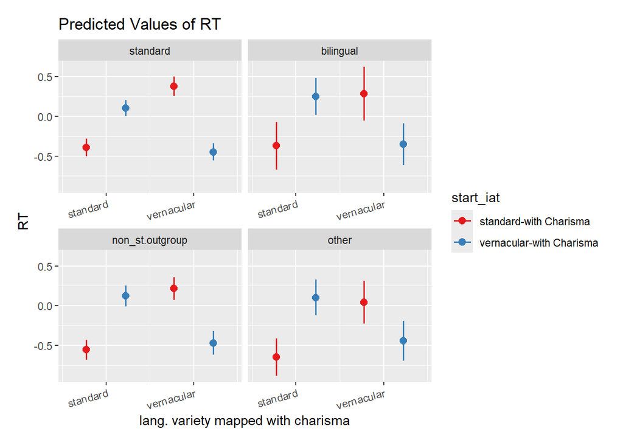

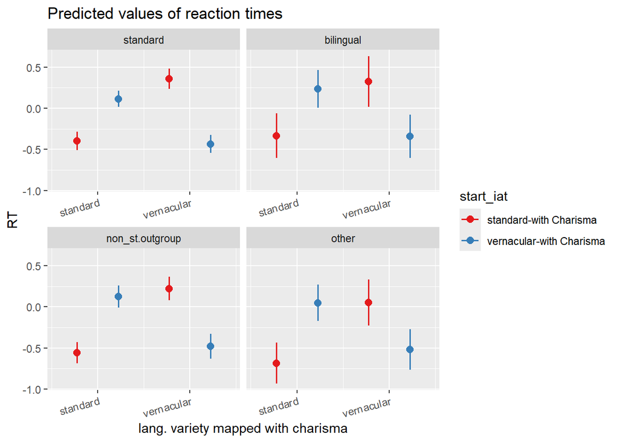

```
## Linear mixed model fit by REML. t-tests use Satterthwaite's method [
## lmerModLmerTest]
## Formula: penal_RTs ~ charisma_lang_var * start_iat * bundesland + trialcount +
##     age + leadership_lang_var + stim_cat + (charisma_lang_var |
##     bilendi_id) + (start_iat | stimulus_ID)
##    Data: Four_Out
## Control: lmerControl(optimizer = "bobyqa", optCtrl = list(maxfun = 2e+05))
##
## REML criterion at convergence: 153711.3
##
## Scaled residuals:
##     Min      1Q  Median      3Q     Max
## -6.3011 -0.6201 -0.1211  0.5476 13.5314
##
## Random effects:
##  Groups      Name                              Variance Std.Dev. Corr
##  bilendi_id  (Intercept)                       0.28990  0.53843
##              charisma_lang_varvernacular       0.20927  0.45746  -0.25
##  stimulus_ID (Intercept)                       0.01662  0.12892
##              start_iatvernacular-with Charisma 0.00189  0.04347  -0.35
##  Residual                                      0.59825  0.77347
## Number of obs: 64365, groups:  bilendi_id, 537; stimulus_ID, 303
##
## Fixed effects:
##                                                                                                  Estimate
## (Intercept)                                                                                     5.071e-01
## charisma_lang_varvernacular                                                                     7.440e-01
## start_iatvernacular-with Charisma                                                               5.852e-01
## bundeslandBayern                                                                               -1.720e-01
## bundeslandBerlin                                                                               -3.952e-01
## bundeslandBrandenburg                                                                           1.349e+00
## bundeslandBremen                                                                                2.135e-01
## bundeslandHamburg                                                                              -5.371e-02
## bundeslandHessen                                                                               -4.435e-02
## bundeslandMecklenburg-Vorpommern                                                               -2.980e-01
## bundeslandNiedersachsen                                                                        -7.324e-02
## bundeslandNordrhein-Westfalen                                                                  -1.015e-02
## bundeslandRheinland-Pfalz                                                                      -2.034e-01
## bundeslandSaarland                                                                              2.710e-01
## bundeslandSachsen                                                                              -2.352e-02
```

[output cut: 385 more lines]

```
## charisma_lang_varvernacular:start_iatvernacular-with Charisma:bundeslandBrandenburg
## charisma_lang_varvernacular:start_iatvernacular-with Charisma:bundeslandBremen
## charisma_lang_varvernacular:start_iatvernacular-with Charisma:bundeslandHamburg
## charisma_lang_varvernacular:start_iatvernacular-with Charisma:bundeslandHessen
## charisma_lang_varvernacular:start_iatvernacular-with Charisma:bundeslandMecklenburg-Vorpommern
## charisma_lang_varvernacular:start_iatvernacular-with Charisma:bundeslandNiedersachsen
## charisma_lang_varvernacular:start_iatvernacular-with Charisma:bundeslandNordrhein-Westfalen
## charisma_lang_varvernacular:start_iatvernacular-with Charisma:bundeslandRheinland-Pfalz
## charisma_lang_varvernacular:start_iatvernacular-with Charisma:bundeslandSaarland
## charisma_lang_varvernacular:start_iatvernacular-with Charisma:bundeslandSachsen                .
## charisma_lang_varvernacular:start_iatvernacular-with Charisma:bundeslandSachsen-Anhalt         .
## charisma_lang_varvernacular:start_iatvernacular-with Charisma:bundeslandSchleswig-Holstein
## charisma_lang_varvernacular:start_iatvernacular-with Charisma:bundeslandThüringen
## ---
## Signif. codes:  0 '***' 0.001 '**' 0.01 '*' 0.05 '.' 0.1 ' ' 1
```

```
##
## Correlation matrix not shown by default, as p = 68 > 12.
## Use print(x, correlation=TRUE)  or
##     vcov(x)        if you need it
```

```
## Type III Analysis of Variance Table with Satterthwaite's method
##                                         Sum Sq Mean Sq NumDF DenDF   F value
## charisma_lang_var                         7.43    7.43     1   505   12.4116
## start_iat                                 3.30    3.30     1   503    5.5183
## bundesland                               18.00    1.20    15   502    2.0058
## trialcount                             1174.57 1174.57     1 63036 1963.3280
## age                                      12.42   12.42     1   502   20.7539
## leadership_lang_var                       2.18    2.18     1   512    3.6517
## stim_cat                                 66.77   66.77     1   263  111.6091
## charisma_lang_var:start_iat             225.22  225.22     1   853  376.4671
## charisma_lang_var:bundesland              8.48    0.57    15   505    0.9452
## start_iat:bundesland                     17.32    1.15    15   502    1.9300
## charisma_lang_var:start_iat:bundesland    5.85    0.39    15   505    0.6523
##                                           Pr(>F)
## charisma_lang_var                      0.0004654 ***
## start_iat                              0.0192040 *
## bundesland                             0.0134694 *
## trialcount                             < 2.2e-16 ***
## age                                    6.563e-06 ***
## leadership_lang_var                    0.0565692 .
## stim_cat                               < 2.2e-16 ***
## charisma_lang_var:start_iat            < 2.2e-16 ***
## charisma_lang_var:bundesland           0.5132724
## start_iat:bundesland                   0.0186016 *
## charisma_lang_var:start_iat:bundesland 0.8311889
## ---
## Signif. codes:  0 '***' 0.001 '**' 0.01 '*' 0.05 '.' 0.1 ' ' 1
```

### 3.3.4 Focus gender

#### Speaker gender

no significant difference between female vernacular - male vernacular & female standard - male standard

```
## Linear mixed model fit by REML. t-tests use Satterthwaite's method [
## lmerModLmerTest]
## Formula: penal_RTs ~ charisma_lang_var * start_iat * speaker_gender +
##     trialcount + leadership_lang_var + stim_cat + age + (charisma_lang_var |
##     bilendi_id) + (start_iat | stimulus_ID)
##    Data: Four_Out_gend
## Control: lmerControl(optimizer = "bobyqa", optCtrl = list(maxfun = 2e+05))
##
## REML criterion at convergence: 153437.2
##
## Scaled residuals:
##     Min      1Q  Median      3Q     Max
## -6.2917 -0.6200 -0.1214  0.5476 13.5265
##
## Random effects:
##  Groups      Name                              Variance Std.Dev. Corr
##  bilendi_id  (Intercept)                       0.300630 0.54830
##              charisma_lang_varvernacular       0.207183 0.45517  -0.24
##  stimulus_ID (Intercept)                       0.016582 0.12877
##              start_iatvernacular-with Charisma 0.001903 0.04362  -0.35
##  Residual                                      0.598567 0.77367
## Number of obs: 64245, groups:  bilendi_id, 536; stimulus_ID, 303
##
## Fixed effects:
##                                                                                    Estimate
## (Intercept)                                                                       4.084e-01
## charisma_lang_varvernacular                                                       7.173e-01
## start_iatvernacular-with Charisma                                                 5.589e-01
## speaker_gendermale                                                                4.022e-02
## trialcount                                                                       -7.823e-03
## leadership_lang_var2                                                              9.187e-02
## stim_catleadership                                                                1.857e-01
## age                                                                               1.097e-01
## charisma_lang_varvernacular:start_iatvernacular-with Charisma                    -1.279e+00
## charisma_lang_varvernacular:speaker_gendermale                                    8.360e-02
## start_iatvernacular-with Charisma:speaker_gendermale                              6.667e-02
## charisma_lang_varvernacular:start_iatvernacular-with Charisma:speaker_gendermale -9.380e-02
##                                                                                  Std. Error
## (Intercept)                                                                       5.872e-02
## charisma_lang_varvernacular                                                       4.583e-02
```

[output cut: 75 more lines]

```
## chrsm_ln_:_  0.160 -0.665 -0.133 -0.258  0.000  0.000  0.000  0.000  0.456
## strt_tv-C:_  0.462 -0.128 -0.694 -0.719  0.000 -0.044  0.000  0.034  0.165
## chr__:_-C:_ -0.118  0.488  0.183  0.189  0.000  0.000  0.000  0.000 -0.626
##             ch__:_ s_-C:_
## chrsm_lng_v
## strt_tvrn-C
## spkr_gndrml
## trialcount
## ldrshp_ln_2
## stm_ctldrsh
## age
## chrsm__:_-C
## chrsm_ln_:_
## strt_tv-C:_  0.193
## chr__:_-C:_ -0.734 -0.263
```

```
## Type III Analysis of Variance Table with Satterthwaite's method
##                                             Sum Sq Mean Sq NumDF DenDF
## charisma_lang_var                            12.92   12.92     1   532
## start_iat                                     1.34    1.34     1   533
## speaker_gender                                2.06    2.06     1   621
## trialcount                                 1175.43 1175.43     1 62916
## leadership_lang_var                           2.26    2.26     1   540
## stim_cat                                     66.38   66.38     1   263
## age                                          13.24   13.24     1   530
## charisma_lang_var:start_iat                 387.51  387.51     1  1343
## charisma_lang_var:speaker_gender              0.47    0.47     1   532
## start_iat:speaker_gender                      0.03    0.03     1   533
## charisma_lang_var:start_iat:speaker_gender    0.77    0.77     1   532
##                                              F value    Pr(>F)
## charisma_lang_var                            21.5834 4.276e-06 ***
## start_iat                                     2.2363   0.13540
## speaker_gender                                3.4361   0.06426 .
## trialcount                                 1963.7427 < 2.2e-16 ***
## leadership_lang_var                           3.7797   0.05240 .
## stim_cat                                    110.9061 < 2.2e-16 ***
## age                                          22.1275 3.259e-06 ***
## charisma_lang_var:start_iat                 647.4040 < 2.2e-16 ***
## charisma_lang_var:speaker_gender              0.7891   0.37476
## start_iat:speaker_gender                      0.0434   0.83498
## charisma_lang_var:start_iat:speaker_gender    1.2885   0.25684
## ---
## Signif. codes:  0 '***' 0.001 '**' 0.01 '*' 0.05 '.' 0.1 ' ' 1
```

```
## Note: D.f. calculations have been disabled because the number of observations exceeds 3000.
## To enable adjustments, add the argument 'pbkrtest.limit = 64245' (or larger)
## [or, globally, 'set emm_options(pbkrtest.limit = 64245)' or larger];
## but be warned that this may result in large computation time and memory use.
```

```
## Note: D.f. calculations have been disabled because the number of observations exceeds 3000.
## To enable adjustments, add the argument 'lmerTest.limit = 64245' (or larger)
## [or, globally, 'set emm_options(lmerTest.limit = 64245)' or larger];
## but be warned that this may result in large computation time and memory use.
```

```
## NOTE: Results may be misleading due to involvement in interactions
```

```
## $emmeans
##  charisma_lang_var speaker_gender    emmean     SE  df asymp.LCL asymp.UCL
##  standard          female         -0.076810 0.0363 Inf   -0.1480   -0.0056
##  vernacular        female          0.000808 0.0406 Inf   -0.0788    0.0804
##  standard          male           -0.003253 0.0359 Inf   -0.0736    0.0671
##  vernacular        male            0.111066 0.0401 Inf    0.0325    0.1897
##
## Results are averaged over the levels of: start_iat, leadership_lang_var, stim_cat
## Degrees-of-freedom method: asymptotic
## Confidence level used: 0.95
##
## $contrasts
##  contrast                            estimate     SE  df z.ratio p.value
##  standard female - vernacular female -0.07762 0.0294 Inf  -2.639  0.0414
##  standard female - standard male     -0.07356 0.0506 Inf  -1.454  0.4655
##  standard female - vernacular male   -0.18788 0.0537 Inf  -3.500  0.0026
##  vernacular female - standard male    0.00406 0.0538 Inf   0.076  0.9998
##  vernacular female - vernacular male -0.11026 0.0567 Inf  -1.946  0.2090
##  standard male - vernacular male     -0.11432 0.0290 Inf  -3.940  0.0005
##
## Results are averaged over the levels of: start_iat, leadership_lang_var, stim_cat
## Degrees-of-freedom method: asymptotic
## P value adjustment: tukey method for comparing a family of 4 estimates
```

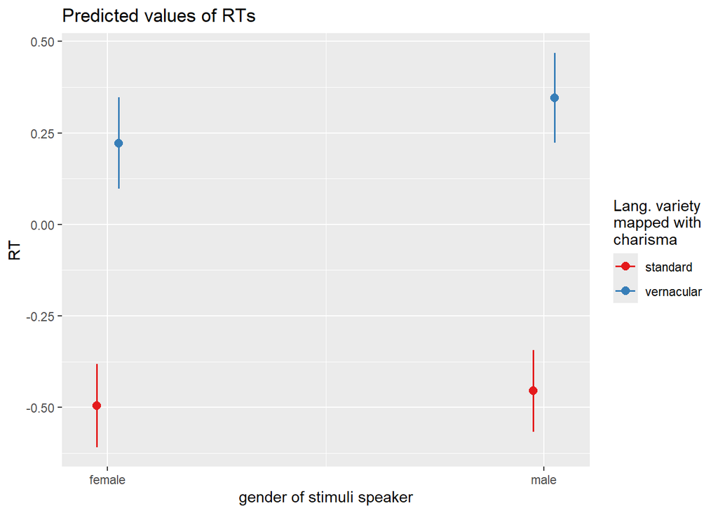

#### Participant gender  
not significant difference between female vernacular - male vernacular & female standard - male standard

```
## Linear mixed model fit by REML. t-tests use Satterthwaite's method [
## lmerModLmerTest]
## Formula: penal_RTs ~ charisma_lang_var * start_iat * pp_gender + trialcount +
##     leadership_lang_var + stim_cat + (charisma_lang_var | bilendi_id) +
##     (start_iat | stimulus_ID)
##    Data: Four_Out_gend
## Control: lmerControl(optimizer = "bobyqa", optCtrl = list(maxfun = 2e+05))
##
## REML criterion at convergence: 153455.2
##
## Scaled residuals:
##     Min      1Q  Median      3Q     Max
## -6.2932 -0.6200 -0.1215  0.5481 13.5200
##
## Random effects:
##  Groups      Name                              Variance Std.Dev. Corr
##  bilendi_id  (Intercept)                       0.30856  0.55548
##              charisma_lang_varvernacular       0.20770  0.45574  -0.21
##  stimulus_ID (Intercept)                       0.01659  0.12880
##              start_iatvernacular-with Charisma 0.00190  0.04359  -0.35
##  Residual                                      0.59857  0.77367
## Number of obs: 64245, groups:  bilendi_id, 536; stimulus_ID, 303
##
## Fixed effects:
##                                                                               Estimate
## (Intercept)                                                                  4.124e-01
## charisma_lang_varvernacular                                                  7.797e-01
## start_iatvernacular-with Charisma                                            6.313e-01
## pp_gendermale                                                                4.530e-02
## trialcount                                                                  -7.823e-03
## leadership_lang_var2                                                         8.953e-02
## stim_catleadership                                                           1.858e-01
## charisma_lang_varvernacular:start_iatvernacular-with Charisma               -1.337e+00
## charisma_lang_varvernacular:pp_gendermale                                   -4.678e-02
## start_iatvernacular-with Charisma:pp_gendermale                             -9.334e-02
## charisma_lang_varvernacular:start_iatvernacular-with Charisma:pp_gendermale  2.583e-02
##                                                                             Std. Error
## (Intercept)                                                                  5.654e-02
## charisma_lang_varvernacular                                                  4.349e-02
## start_iatvernacular-with Charisma                                            6.836e-02
```

[output cut: 67 more lines]

```
## chrsm__:_-C  0.017 -0.765 -0.314 -0.098  0.493  0.000  0.000
## chrsm_ln_:_  0.132 -0.615 -0.109 -0.236  0.000  0.000  0.000  0.415
## strt_tv-C:_  0.432 -0.107 -0.657 -0.737  0.000 -0.050  0.000  0.138    0.174
## chr__:_-C:_ -0.097  0.453  0.155  0.174  0.000  0.000  0.000 -0.587   -0.737
##             s_-C:_
## chrsm_lng_v
## strt_tvrn-C
## pp_genderml
## trialcount
## ldrshp_ln_2
## stm_ctldrsh
## chrsm__:_-C
## chrsm_ln_:_
## strt_tv-C:_
## chr__:_-C:_ -0.236
```

```
## Type III Analysis of Variance Table with Satterthwaite's method
##                                        Sum Sq Mean Sq NumDF DenDF   F value
## charisma_lang_var                       12.33   12.33     1   532   20.5955
## start_iat                                1.51    1.51     1   533    2.5241
## pp_gender                                0.08    0.08     1   531    0.1413
## trialcount                            1175.43 1175.43     1 62916 1963.7468
## leadership_lang_var                      2.06    2.06     1   541    3.4483
## stim_cat                                66.45   66.45     1   263  111.0215
## charisma_lang_var:start_iat            383.45  383.45     1  1331  640.6142
## charisma_lang_var:pp_gender              0.40    0.40     1   532    0.6641
## start_iat:pp_gender                      0.41    0.41     1   531    0.6817
## charisma_lang_var:start_iat:pp_gender    0.06    0.06     1   532    0.0966
##                                          Pr(>F)
## charisma_lang_var                     7.021e-06 ***
## start_iat                               0.11271
## pp_gender                               0.70712
## trialcount                            < 2.2e-16 ***
## leadership_lang_var                     0.06386 .
## stim_cat                              < 2.2e-16 ***
## charisma_lang_var:start_iat           < 2.2e-16 ***
## charisma_lang_var:pp_gender             0.41548
## start_iat:pp_gender                     0.40936
## charisma_lang_var:start_iat:pp_gender   0.75607
## ---
## Signif. codes:  0 '***' 0.001 '**' 0.01 '*' 0.05 '.' 0.1 ' ' 1
```

```
## Note: D.f. calculations have been disabled because the number of observations exceeds 3000.
## To enable adjustments, add the argument 'pbkrtest.limit = 64245' (or larger)
## [or, globally, 'set emm_options(pbkrtest.limit = 64245)' or larger];
## but be warned that this may result in large computation time and memory use.
```

```
## Note: D.f. calculations have been disabled because the number of observations exceeds 3000.
## To enable adjustments, add the argument 'lmerTest.limit = 64245' (or larger)
## [or, globally, 'set emm_options(lmerTest.limit = 64245)' or larger];
## but be warned that this may result in large computation time and memory use.
```

```
## $emmeans
##  charisma_lang_var start_iat                pp_gender emmean     SE  df
##  standard          standard-with Charisma   female    -0.353 0.0493 Inf
##  vernacular        standard-with Charisma   female     0.426 0.0562 Inf
##  standard          vernacular-with Charisma female     0.278 0.0475 Inf
##  vernacular        vernacular-with Charisma female    -0.279 0.0541 Inf
##  standard          standard-with Charisma   male      -0.308 0.0558 Inf
##  vernacular        standard-with Charisma   male       0.425 0.0636 Inf
##  standard          vernacular-with Charisma male       0.230 0.0495 Inf
##  vernacular        vernacular-with Charisma male      -0.348 0.0564 Inf
##  asymp.LCL asymp.UCL
##     -0.450    -0.257
##      0.316     0.536
##      0.185     0.371
##     -0.385    -0.173
##     -0.418    -0.199
##      0.300     0.549
##      0.133     0.327
##     -0.459    -0.238
##
## Results are averaged over the levels of: leadership_lang_var, stim_cat
## Degrees-of-freedom method: asymptotic
## Confidence level used: 0.95
##
## $contrasts
##  contrast
##  (standard standard-with Charisma female) - (vernacular standard-with Charisma female)
##  (standard standard-with Charisma female) - (standard vernacular-with Charisma female)
##  (standard standard-with Charisma female) - (vernacular vernacular-with Charisma female)
##  (standard standard-with Charisma female) - (standard standard-with Charisma male)
##  (standard standard-with Charisma female) - (vernacular standard-with Charisma male)
##  (standard standard-with Charisma female) - (standard vernacular-with Charisma male)
##  (standard standard-with Charisma female) - (vernacular vernacular-with Charisma male)
##  (vernacular standard-with Charisma female) - (standard vernacular-with Charisma female)
##  (vernacular standard-with Charisma female) - (vernacular vernacular-with Charisma female)
##  (vernacular standard-with Charisma female) - (standard standard-with Charisma male)
##  (vernacular standard-with Charisma female) - (vernacular standard-with Charisma male)
##  (vernacular standard-with Charisma female) - (standard vernacular-with Charisma male)
##  (vernacular standard-with Charisma female) - (vernacular vernacular-with Charisma male)
##  (standard vernacular-with Charisma female) - (vernacular vernacular-with Charisma female)
```

[output cut: 32 more lines]

```
##   0.62622 0.0735 Inf   8.521  <.0001
##   0.02872 0.0757 Inf   0.379  0.9999
##  -0.70418 0.0832 Inf  -8.464  <.0001
##  -0.50920 0.0731 Inf  -6.969  <.0001
##   0.06898 0.0763 Inf   0.905  0.9857
##  -0.73290 0.0486 Inf -15.081  <.0001
##  -0.53792 0.0743 Inf  -7.238  <.0001
##   0.04026 0.0775 Inf   0.520  0.9996
##   0.19497 0.0788 Inf   2.476  0.2059
##   0.77316 0.0848 Inf   9.121  <.0001
##   0.57818 0.0436 Inf  13.254  <.0001
##
## Results are averaged over the levels of: leadership_lang_var, stim_cat
## Degrees-of-freedom method: asymptotic
## P value adjustment: tukey method for comparing a family of 8 estimates
```

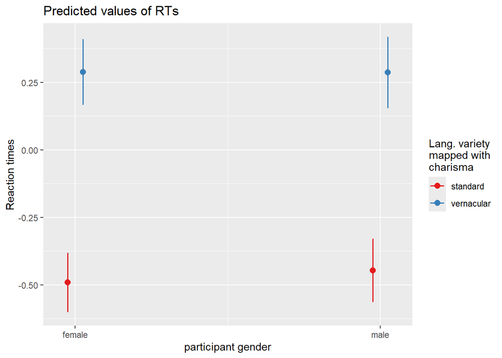

#### Interaction participant & speaker gender

```
## Linear mixed model fit by REML. t-tests use Satterthwaite's method [
## lmerModLmerTest]
## Formula: penal_RTs ~ charisma_lang_var * pp_gender * speaker_gender +
##     start_iat + trialcount + leadership_lang_var + stim_cat +
##     (charisma_lang_var | bilendi_id) + (start_iat | stimulus_ID)
##    Data: Four_Out_gend
## Control: lmerControl(optimizer = "bobyqa", optCtrl = list(maxfun = 2e+05))
##
## REML criterion at convergence: 153953.2
##
## Scaled residuals:
##     Min      1Q  Median      3Q     Max
## -6.4062 -0.6196 -0.1237  0.5482 13.4303
##
## Random effects:
##  Groups      Name                              Variance Std.Dev. Corr
##  bilendi_id  (Intercept)                       0.329327 0.57387
##              charisma_lang_varvernacular       0.480524 0.69320  -0.33
##  stimulus_ID (Intercept)                       0.016611 0.12888
##              start_iatvernacular-with Charisma 0.001928 0.04391  -0.35
##  Residual                                      0.599298 0.77414
## Number of obs: 64245, groups:  bilendi_id, 536; stimulus_ID, 303
##
## Fixed effects:
##                                                                Estimate
## (Intercept)                                                   4.721e-01
## charisma_lang_varvernacular                                   8.906e-02
## pp_gendermale                                                -5.044e-02
## speaker_gendermale                                            1.248e-02
## start_iatvernacular-with Charisma                             1.580e-01
## trialcount                                                   -6.266e-03
## leadership_lang_var2                                          8.464e-02
## stim_catleadership                                            1.858e-01
## charisma_lang_varvernacular:pp_gendermale                    -1.054e-01
## charisma_lang_varvernacular:speaker_gendermale                6.355e-04
## pp_gendermale:speaker_gendermale                              1.049e-01
## charisma_lang_varvernacular:pp_gendermale:speaker_gendermale  5.670e-02
##                                                              Std. Error
## (Intercept)                                                   6.181e-02
## charisma_lang_varvernacular                                   5.777e-02
```

[output cut: 49 more lines]

```
## chrsm_lng_vrvrnclr:s_  0.178 -0.695 -0.155 -0.333 -0.002  0.019  0.000  0.000
## pp_gndrml:_            0.354 -0.160 -0.717 -0.663  0.048  0.008 -0.039  0.000
## chrsm__:_:_           -0.117  0.470  0.243  0.226  0.003 -0.024  0.000  0.000
##                       chrsm_lng_vrvrnclr:p_ chrsm_lng_vrvrnclr:s_ pp_g:_
## chrsm_lng_v
## pp_genderml
## spkr_gndrml
## strt_tvrn-C
## trialcount
## ldrshp_ln_2
## stm_ctldrsh
## chrsm_lng_vrvrnclr:p_
## chrsm_lng_vrvrnclr:s_  0.457
## pp_gndrml:_            0.244                 0.230
## chrsm__:_:_           -0.716                -0.677                -0.340
```

```
## Type III Analysis of Variance Table with Satterthwaite's method
##                                            Sum Sq Mean Sq NumDF  DenDF
## charisma_lang_var                            1.64    1.64     1  410.1
## pp_gender                                    0.33    0.33     1  453.9
## speaker_gender                               1.42    1.42     1  526.8
## start_iat                                    6.48    6.48     1  542.8
## trialcount                                 956.04  956.04     1 8523.8
## leadership_lang_var                          1.85    1.85     1  540.0
## stim_cat                                    66.49   66.49     1  263.3
## charisma_lang_var:pp_gender                  0.94    0.94     1  409.3
## charisma_lang_var:speaker_gender             0.13    0.13     1  409.1
## pp_gender:speaker_gender                     1.08    1.08     1  454.2
## charisma_lang_var:pp_gender:speaker_gender   0.13    0.13     1  409.5
##                                              F value    Pr(>F)
## charisma_lang_var                             2.7390  0.098694 .
## pp_gender                                     0.5441  0.461127
## speaker_gender                                2.3772  0.123721
## start_iat                                    10.8058  0.001077 **
## trialcount                                 1595.2745 < 2.2e-16 ***
## leadership_lang_var                           3.0943  0.079134 .
## stim_cat                                    110.9429 < 2.2e-16 ***
## charisma_lang_var:pp_gender                   1.5708  0.210812
## charisma_lang_var:speaker_gender              0.2226  0.637322
## pp_gender:speaker_gender                      1.8088  0.179324
## charisma_lang_var:pp_gender:speaker_gender    0.2128  0.644815
## ---
## Signif. codes:  0 '***' 0.001 '**' 0.01 '*' 0.05 '.' 0.1 ' ' 1
```

```
## Note: D.f. calculations have been disabled because the number of observations exceeds 3000.
## To enable adjustments, add the argument 'pbkrtest.limit = 64245' (or larger)
## [or, globally, 'set emm_options(pbkrtest.limit = 64245)' or larger];
## but be warned that this may result in large computation time and memory use.
```

```
## Note: D.f. calculations have been disabled because the number of observations exceeds 3000.
## To enable adjustments, add the argument 'lmerTest.limit = 64245' (or larger)
## [or, globally, 'set emm_options(lmerTest.limit = 64245)' or larger];
## but be warned that this may result in large computation time and memory use.
```

```
## $emmeans
##  charisma_lang_var speaker_gender pp_gender  emmean     SE  df asymp.LCL
##  standard          female         female    -0.0374 0.0489 Inf   -0.1332
##  vernacular        female         female     0.0517 0.0621 Inf   -0.0700
##  standard          male           female    -0.0249 0.0506 Inf   -0.1241
##  vernacular        male           female     0.0648 0.0643 Inf   -0.0612
##  standard          female         male      -0.0878 0.0561 Inf   -0.1978
##  vernacular        female         male      -0.1041 0.0712 Inf   -0.2437
##  standard          male           male       0.0296 0.0520 Inf   -0.0724
##  vernacular        male           male       0.0706 0.0661 Inf   -0.0589
##  asymp.UCL
##     0.0584
##     0.1734
##     0.0743
##     0.1908
##     0.0221
##     0.0355
##     0.1315
##     0.2001
##
## Results are averaged over the levels of: start_iat, leadership_lang_var, stim_cat
## Degrees-of-freedom method: asymptotic
## Confidence level used: 0.95
##
## $contrasts
##  contrast                                          estimate     SE  df z.ratio
##  standard female female - vernacular female female -0.08906 0.0578 Inf  -1.542
##  standard female female - standard male female     -0.01248 0.0701 Inf  -0.178
##  standard female female - vernacular male female   -0.10218 0.0805 Inf  -1.270
##  standard female female - standard female male      0.05044 0.0726 Inf   0.695
##  standard female female - vernacular female male    0.06674 0.0849 Inf   0.786
##  standard female female - standard male male       -0.06692 0.0711 Inf  -0.942
##  standard female female - vernacular male male     -0.10796 0.0819 Inf  -1.318
##  vernacular female female - standard male female    0.07658 0.0798 Inf   0.959
##  vernacular female female - vernacular male female -0.01311 0.0891 Inf  -0.147
##  vernacular female female - standard female male    0.13950 0.0821 Inf   1.700
##  vernacular female female - vernacular female male  0.15580 0.0931 Inf   1.674
##  vernacular female female - standard male male      0.02214 0.0807 Inf   0.274
##  vernacular female female - vernacular male male   -0.01890 0.0904 Inf  -0.209
##  standard male female - vernacular male female     -0.08970 0.0598 Inf  -1.500
```

[output cut: 32 more lines]

```
##   0.9405
##   0.6200
##   0.6409
##   0.9999
##   1.0000
##   1.0000
##   0.7827
##   0.5945
##   0.7951
##   0.6161
##   0.9978
##
## Results are averaged over the levels of: start_iat, leadership_lang_var, stim_cat
## Degrees-of-freedom method: asymptotic
## P value adjustment: tukey method for comparing a family of 8 estimates
```

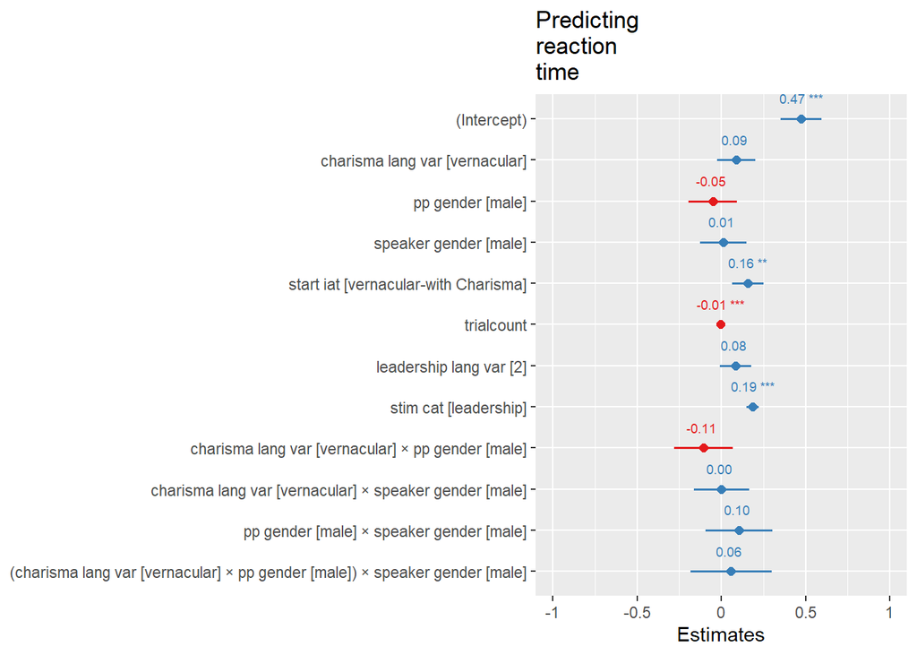

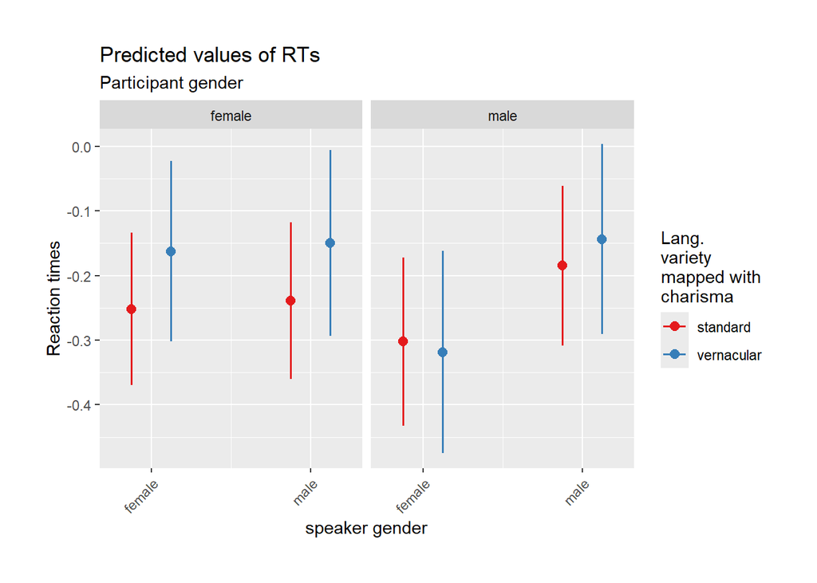

#### Subset analyses gender  
##### female speaker  
comparisons of 2nd block not significant

```
## Linear mixed model fit by REML. t-tests use Satterthwaite's method [
## lmerModLmerTest]
## Formula: penal_RTs ~ charisma_lang_var * start_iat * pp_gender + trialcount +
##     age + leadership_lang_var + stim_cat + (charisma_lang_var |
##     bilendi_id) + (start_iat | stimulus_ID)
##    Data: Four_Out_fem
## Control: lmerControl(optimizer = "bobyqa", optCtrl = list(maxfun = 2e+05))
##
## REML criterion at convergence: 71464.8
##
## Scaled residuals:
##     Min      1Q  Median      3Q     Max
## -6.4798 -0.6545 -0.1180  0.5957 13.0974
##
## Random effects:
##  Groups      Name                              Variance  Std.Dev. Corr
##  bilendi_id  (Intercept)                       0.3559922 0.59665
##              charisma_lang_varvernacular       0.1479912 0.38470  -0.21
##  stimulus_ID (Intercept)                       0.0135568 0.11643
##              start_iatvernacular-with Charisma 0.0007742 0.02782  -0.27
##  Residual                                      0.5251144 0.72465
## Number of obs: 31642, groups:  bilendi_id, 264; stimulus_ID, 147
##
## Fixed effects:
##                                                                               Estimate
## (Intercept)                                                                  4.144e-01
## charisma_lang_varvernacular                                                  6.793e-01
## start_iatvernacular-with Charisma                                            5.574e-01
## pp_gendermale                                                               -2.363e-02
## trialcount                                                                  -7.397e-03
## age                                                                          9.629e-02
## leadership_lang_var2                                                         4.879e-02
## stim_catleadership                                                           1.780e-01
## charisma_lang_varvernacular:start_iatvernacular-with Charisma               -1.194e+00
## charisma_lang_varvernacular:pp_gendermale                                   -9.709e-04
## start_iatvernacular-with Charisma:pp_gendermale                             -7.971e-02
## charisma_lang_varvernacular:start_iatvernacular-with Charisma:pp_gendermale -1.855e-02
##                                                                             Std. Error
## (Intercept)                                                                  8.257e-02
## charisma_lang_varvernacular                                                  5.127e-02
```

[output cut: 75 more lines]

```
## chrsm_ln_:_  0.122 -0.563 -0.099 -0.235  0.000  0.000  0.000  0.000  0.366
## strt_tv-C:_  0.391 -0.098 -0.638 -0.739  0.000  0.076 -0.022  0.000  0.129
## chr__:_-C:_ -0.090  0.417  0.149  0.174  0.000  0.000  0.000  0.000 -0.549
##             ch__:_ s_-C:_
## chrsm_lng_v
## strt_tvrn-C
## pp_genderml
## trialcount
## age
## ldrshp_ln_2
## stm_ctldrsh
## chrsm__:_-C
## chrsm_ln_:_
## strt_tv-C:_  0.174
## chr__:_-C:_ -0.740 -0.235
```